# PDFRpoert

my_name 2023-08-25

#load libraries

```r
library(tidyverse)
library(knitr)
library(corrplot)
library(kableExtra)
```

# load data

```r
space<- read_csv("SPACE_wide_2022.csv")
space[space==999998] <- NA
```

# Data preparatio

```r
df<- space %>%
  select(AGE, D1, EDUCATION, D6_1, D6_2A, D6_2B, HHSIZE, DEPCHILDREN, INCOME,COUNTRY,
         QQ1A_1,,QQ1A_2,QQ1A_3,QQ1D,
         starts_with(c("QA5A_", "QA6A_","QA7A_","QA7AI_", "QA7AII_","QA8A_", "QA8AI_1")))%>%
  mutate(AGE=case_when(AGE==1~"18-24",
                       AGE==2~"25-29",
                       AGE==3~"30-34",
                       AGE==4~"35-39",
                       AGE==5~"40-44",
                       AGE==6~"45-49",
                       AGE==7~"50-54",
                       AGE==8~"55-59",
                       AGE==9~"60-64",
                       AGE==10~"64-69",
                       AGE==11~"70-74",
                       AGE==12~"75+"),
         D1=case_when(D1==1~'Male',
                      D1==2~"Female",
                      D1==3~"Other, non-binary"),
         EDUCATION= case_when(EDUCATION==1~"Primary/lower secondary education",
                              EDUCATION==2~"Upper/post-secondary education",
                              EDUCATION==3 ~"University/PhD/research",
                              EDUCATION=='=999998'~"Refusal / No answer"),
         D6_1= case_when(D6_1==1~"Self-employed",
                         D6_1==2~"Employee",
                         D6_1==3~"Without a professional activity or student",
                         D6_1=="999998"~"Refusal / No answer"),
         D6_2A= case_when(D6_2A==1~"General management, director or top management",
                          D6_2A==2~"Middle management or other management (e.g. department head)",
                          D6_2A==3~"Employed professional (e.g. doctor, lawyer, accountant, architect)",
                          D6_2A==4~"Employed position, working mainly at a desk",
                          D6_2A==5~"Employed position, not at a desk",
                          D6_2A==6~"Manual worker",
                          D6_2A==7~"Other employee",
                          D6_2A==999998~"Refusal / No answer"),
         D6_2B= case_when(D6_2B==1~ "Responsible for housework (e.g. ordinary shopping, looking after home and family)",
                          D6_2B==2~ "Student (full-time)",
                          D6_2B==3~ "Unemployed or temporarily not working",
                          D6_2B==4~ "Retired or unable to work through illness",
                          D6_2B==5~ "Other",
                          D6_2B==999998~    "Refusal / No answer"),
         INCOME= case_when(INCOME==1~   "EUR 750 or less",
                           INCOME==2~   "Between EUR 751 and EUR 1,500",
                           INCOME==3~   "Between EUR 1,501 and EUR 2,500",
                           INCOME==4~"Between EUR 2,501 and EUR 4,000",
                           INCOME==5~   "More than EUR 4,000",
                           INCOME==999998~  "Refusal")

  )
```

# Correlation for Demographic

```r
### correlation ####
df_cor<- space %>%
  select(AGE, D1, EDUCATION, D6_1, D6_2A, D6_2B, HHSIZE, DEPCHILDREN, INCOME)

df_cor[df_cor>100]<- NA

cor_mat<-cor(df_cor,use='pairwise.complete.obs')
```

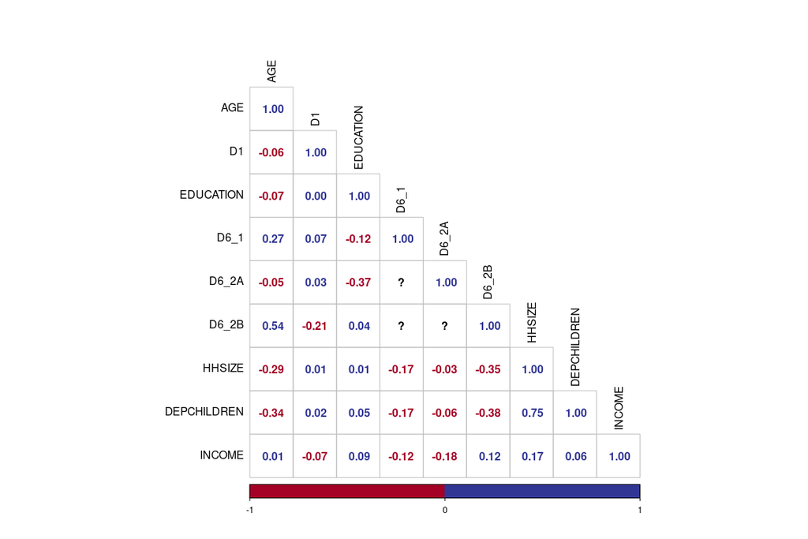

```r
corrplot(cor_mat, method = 'number',col = COL2('RdYlBu', 2),
         type = 'lower', tl.col='black')
```

# Visualization of the variables

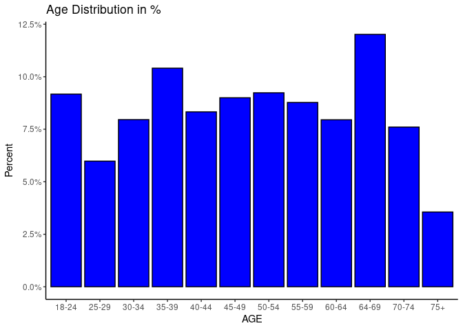

```r
ggplot(df, aes(AGE)) +
  geom_bar(aes(y = (..count..)/sum(..count..)), fill="blue", color="black") +
  scale_y_continuous(labels=scales::percent) +
  labs(y = "Percent", title = "Age Distribution in %")+
  theme_classic()
```

```r
#The plot shows that most of the people who took part in the
# survey falls between 64-69 years of age. The group with over 75 years had the least people
```

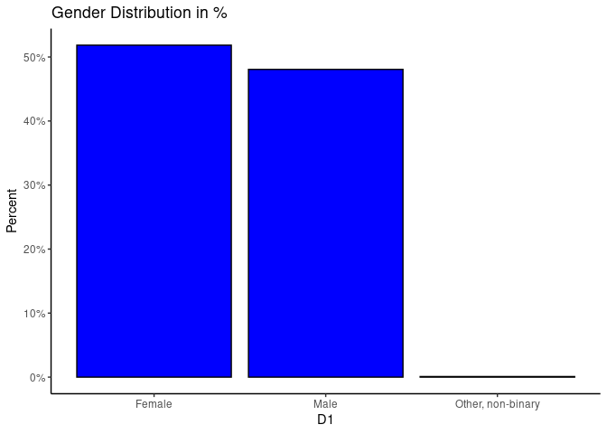

```r
# Gender
ggplot(df, aes(D1)) +
  geom_bar(aes(y = (..count..)/sum(..count..)),fill="blue", color="black") +
  scale_y_continuous(labels=scales::percent) +
  labs(y = "Percent", fill="day") +
  labs(y = "Percent", title = "Gender Distribution in %")+
  theme_classic()
```

```r
#Females are slightly higher than males in the survey.
```

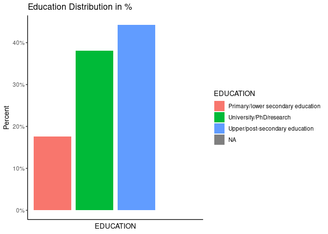

```r
# Education
ggplot(df, aes(EDUCATION, fill=EDUCATION)) +
  geom_bar(aes(y = (..count..)/sum(..count..))) +
  scale_y_continuous(labels=scales::percent) +
  labs(y = "Percent", title = "Education Distribution in %")+
  theme_classic()+
  theme(axis.text.x = element_text(angle = 30, vjust = 0.5, hjust=1))+
  theme(
    # axis.title.x = element_blank(),
    axis.text.x = element_blank(),
    axis.ticks.x = element_blank()
  )
```

```r
# most the people who took part in the survey have attained secondary education.
```

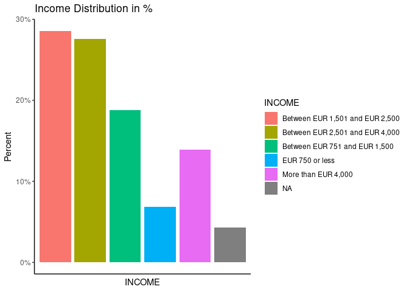

```r
#Income
ggplot(df, aes(INCOME, fill= INCOME)) +
  geom_bar(aes(y = (..count..)/sum(..count..))) +
  scale_y_continuous(labels=scales::percent) +
  labs(y = "Percent", title = "Income Distribution in %")+
  theme_classic()+
  theme(axis.text.x = element_text(angle = 30, vjust = 0.5, hjust=1))+
  theme(
    # axis.title.x = element_blank(),
    axis.text.x = element_blank(),
    axis.ticks.x = element_blank()
  )
```

```r
#Majority of the people earn between 1510 and 2500 euros
```

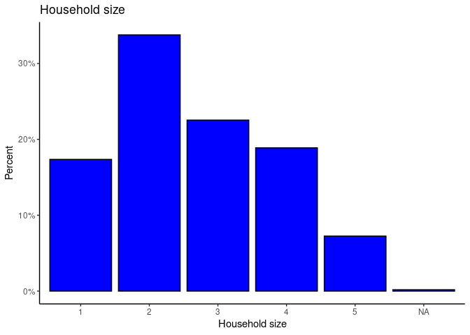

```r
#HHSIZE
ggplot(df, aes(factor(HHSIZE))) +
  geom_bar(aes(y = (..count..)/sum(..count..)),fill="blue", color="black") +
  scale_y_continuous(labels=scales::percent) +
  labs(y = "Percent", title = "Household size",
       x="Household size")+
  theme_classic()
```

```r
#majority of the households have atmost 2 people per household.
```

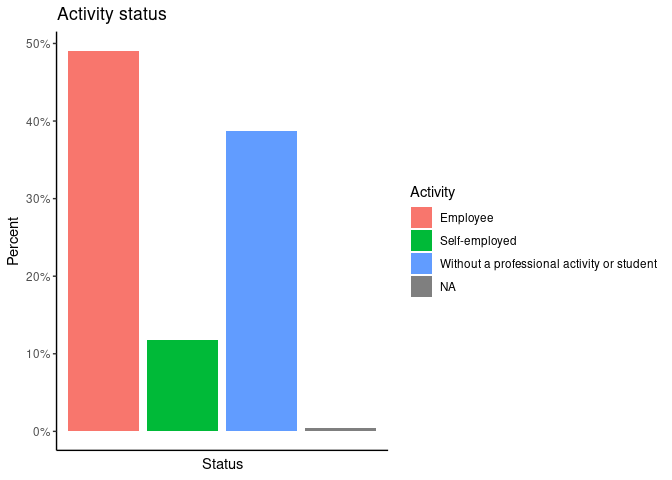

```r
#Activity status
ggplot(df, aes(factor(D6_1), fill=factor(D6_1))) +
  geom_bar(aes(y = (..count..)/sum(..count..))) +
  scale_y_continuous(labels=scales::percent) +
  labs(y = "Percent", title = "Activity status",
       x="Status",fill="Activity")+
  theme_classic()+
  theme(
    # axis.title.x = element_blank(),
    axis.text.x = element_blank(),
    axis.ticks.x = element_blank()
  )
```

```r
#Almost 50% of the people are employees.
```

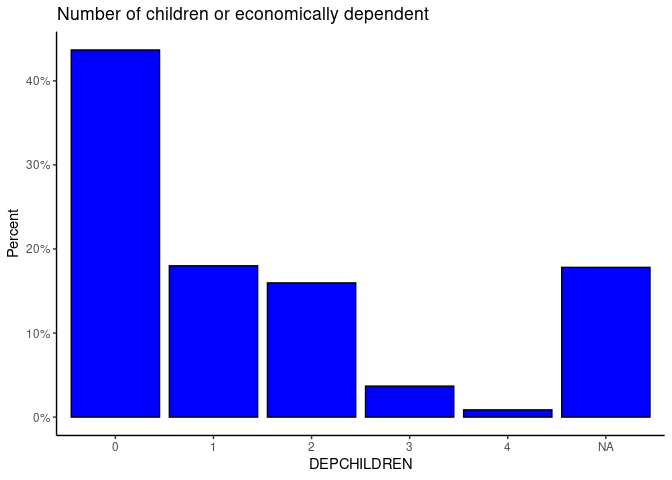

```r
#DEPCHILDREN
ggplot(df, aes(factor(DEPCHILDREN))) +
  geom_bar(aes(y = (..count..)/sum(..count..)),fill="blue", color="black") +
  scale_y_continuous(labels=scales::percent) +
  labs(y = "Percent", title = "Number of children or economically dependent",
       x="DEPCHILDREN")+
  theme_classic()
```

```r
#Over 40% of the participants (majority) do not have dependents.
```

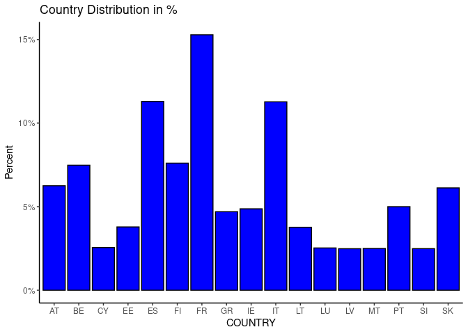

```r
#Country
ggplot(df, aes(COUNTRY)) +
  geom_bar(aes(y = (..count..)/sum(..count..)),fill="blue", color="black") +
  scale_y_continuous(labels=scales::percent) +
  labs(y = "Percent", title = "Country Distribution in %")+
  theme_classic()
```

```r
#Most of the participants are from france followed by italy and spain comes in at third position
```

# Pop holding Bundles of payment instruments in percentage

```r
POS<- space%>%
  select(QQ1A_1,,QQ1A_2,QQ1A_3,QQ1D)%>%
  mutate(QQ1D= case_when(
    QQ1D==1~    "Yes, it is available for me",
    QQ1D==2~    "No, it is not available for me",
    QQ1D==3~    "heard aboutservice, not sure if available",
    QQ1D==4~    "I have not heard about this service",
    QQ1D==999999~   "Don't know"

  ))

Bundles<-count(POS,QQ1A_1,QQ1A_2, QQ1A_3,QQ1D ) %>% ungroup()%>%
  mutate(n= round((n/sum(n))*100,2))%>%
  arrange(desc(n))%>%
  mutate(n= paste0(n," %"))%>%
  head(15)

names(Bundles)<- c("account","crdit.dbit",
                   "crypto", "instnt",
                   "Pop")
kable(Bundles, align = "l")
```

| account | crdit.dbit | crypto | instnt | Pop |
| --- | --- | --- | --- | --- |
| 1 | 1 | 0 | Yes, it is available for me | 39.36 % |
| 1 | 1 | 0 | heard aboutservice, not sure if available | 14.05 % |
| 1 | 1 | 0 | No, it is not available for me | 13.24 % |
| 1 | 1 | 0 | I have not heard about this service | 11.18 % |
| 0 | 1 | 0 | Yes, it is available for me | 4.22 % |
| 1 | 0 | 0 | Yes, it is available for me | 3.54 % |
| 1 | 1 | 1 | Yes, it is available for me | 2.69 % |
| 0 | 1 | 0 | No, it is not available for me | 2.29 % |
| 0 | 1 | 0 | heard aboutservice, not sure if available | 1.66 % |
| 0 | 1 | 0 | I have not heard about this service | 1.45 % |
| 1 | 0 | 0 | No, it is not available for me | 1.3 % |
| 1 | 0 | 0 | heard aboutservice, not sure if available | 1.07 % |
| 1 | 0 | 0 | I have not heard about this service | 0.99 % |
| 1 | 1 | 1 | heard aboutservice, not sure if available | 0.54 % |
| 1 | 1 | 1 | I have not heard about this service | 0.37 % |

The table presents the distribution of people holding specific payment instruments based on their access or awareness of various payment services. The columns represent different conditions: “account” (whether they have an account), “credit/debit” (whether they have a credit/debit card), “crypto” (whether they have access to cryptocurrency), “instant” (whether they have access to instant payment services), and “Pop” (the percentage of respondents falling into each category). For example, 39.36% of respondents have an account, hold a credit/debit card, and have access to instant payment services, while 14.05% have the same but are uncertain if instant payment is available to them. This table provides insights into the intersections of various payment methods and respondents’ access or awareness of these methods, helping to understand the usage patterns and familiarity with different payment instruments among the surveyed population.

The above anlysis haave been broken down by various demographic variables as shwon below.

# Pop holding Bundles of payment instruments in percentage by Age

```r
#### Age

POS<- df%>%
  select(QQ1A_1,,QQ1A_2,QQ1A_3,QQ1D, AGE)%>%
  mutate(QQ1D= case_when(
    QQ1D==1~    "Yes, it is available for me",
    QQ1D==2~    "No, it is not available for me",
    QQ1D==3~    "heard aboutservice, not sure if available",
    QQ1D==4~    "I have not heard about this service",
    QQ1D==999999~   "Don't know"

  ))

Bundles<-count(POS,QQ1A_1,QQ1A_2, QQ1A_3,QQ1D ,AGE) %>% ungroup()%>%
  mutate(n= round((n/sum(n))*100,2))%>%
  arrange(desc(n))%>%
  mutate(n= paste0(n," %"))%>%
  head(15)

names(Bundles)<- c("account","crdit.dbit",
                   "crypto", "instnt","AGE",
                   "Pop")

kable(Bundles, align = "l")
```

| account | crdit.dbit | crypto | instnt | AGE | Pop |
| --- | --- | --- | --- | --- | --- |
| 1 | 1 | 0 | Yes, it is available for me | 35-39 | 4.37 % |
| 1 | 1 | 0 | Yes, it is available for me | 64-69 | 4.24 % |
| 1 | 1 | 0 | Yes, it is available for me | 50-54 | 3.93 % |
| 1 | 1 | 0 | Yes, it is available for me | 45-49 | 3.87 % |
| 1 | 1 | 0 | Yes, it is available for me | 30-34 | 3.54 % |
| 1 | 1 | 0 | Yes, it is available for me | 40-44 | 3.52 % |
| 1 | 1 | 0 | Yes, it is available for me | 55-59 | 3.49 % |
| 1 | 1 | 0 | Yes, it is available for me | 18-24 | 3.37 % |
| 1 | 1 | 0 | Yes, it is available for me | 60-64 | 3.09 % |
| 1 | 1 | 0 | Yes, it is available for me | 25-29 | 2.55 % |
| 1 | 1 | 0 | Yes, it is available for me | 70-74 | 2.49 % |
| 1 | 1 | 0 | No, it is not available for me | 64-69 | 1.99 % |
| 1 | 1 | 0 | heard aboutservice, not sure if available | 64-69 | 1.96 % |
| 1 | 1 | 0 | I have not heard about this service | 64-69 | 1.63 % |
| 1 | 1 | 0 | heard aboutservice, not sure if available | 35-39 | 1.36 % |

# Pop holding Bundles of payment instruments in percentage by education

```r
#Education
POS<- df%>%
  select(QQ1A_1,,QQ1A_2,QQ1A_3,QQ1D, EDUCATION)%>%
  mutate(QQ1D= case_when(
    QQ1D==1~    "Yes, it is available for me",
    QQ1D==2~    "No, it is not available for me",
    QQ1D==3~    "heard aboutservice, not sure if available",
    QQ1D==4~    "I have not heard about this service",
    QQ1D==999999~   "Don't know"

  ))

Bundles<-count(POS,QQ1A_1,QQ1A_2, QQ1A_3,QQ1D ,EDUCATION) %>% ungroup()%>%
  mutate(n= round((n/sum(n))*100,2))%>%
  arrange(desc(n))%>%
  mutate(n= paste0(n," %"))%>%
  head(15)

names(Bundles)<- c("account","crdit.dbit",
                   "crypto", "instnt","EDUCATION",
                   "Pop")
kable(Bundles,align = "l")
```

| account | crdit.dbit | crypto | instnt | EDUCATION | Pop |
| --- | --- | --- | --- | --- | --- |
| 1 | 1 | 0 | Yes, it is available for me | Upper/post-secondary education | 17.06 % |
| 1 | 1 | 0 | Yes, it is available for me | University/PhD/research | 15.99 % |
| 1 | 1 | 0 | heard aboutservice, not sure if available | Upper/post-secondary education | 6.34 % |
| 1 | 1 | 0 | Yes, it is available for me | Primary/lower secondary education | 6.29 % |
| 1 | 1 | 0 | No, it is not available for me | Upper/post-secondary education | 5.61 % |
| 1 | 1 | 0 | I have not heard about this service | Upper/post-secondary education | 5.26 % |
| 1 | 1 | 0 | heard aboutservice, not sure if available | University/PhD/research | 5.25 % |
| 1 | 1 | 0 | No, it is not available for me | University/PhD/research | 4.83 % |
| 1 | 1 | 0 | I have not heard about this service | University/PhD/research | 3.94 % |
| 1 | 1 | 0 | No, it is not available for me | Primary/lower secondary education | 2.8 % |
| 1 | 1 | 0 | heard aboutservice, not sure if available | Primary/lower secondary education | 2.45 % |
| 1 | 1 | 0 | I have not heard about this service | Primary/lower secondary education | 1.97 % |
| 0 | 1 | 0 | Yes, it is available for me | Upper/post-secondary education | 1.85 % |
| 1 | 0 | 0 | Yes, it is available for me | Upper/post-secondary education | 1.64 % |
| 0 | 1 | 0 | Yes, it is available for me | University/PhD/research | 1.62 % |

# Pop holding Bundles of payment instruments in percentage by Activity status

```r
## Activity Status
POS<- df%>%
  select(QQ1A_1,,QQ1A_2,QQ1A_3,QQ1D, D6_1)%>%
  mutate(QQ1D= case_when(
    QQ1D==1~    "Yes, it is available for me",
    QQ1D==2~    "No, it is not available for me",
    QQ1D==3~    "heard aboutservice, not sure if available",
    QQ1D==4~    "I have not heard about this service",
    QQ1D==999999~   "Don't know"

  ))

Bundles<-count(POS,QQ1A_1,QQ1A_2, QQ1A_3,QQ1D ,D6_1) %>% ungroup()%>%
  mutate(n= round((n/sum(n))*100,2))%>%
  arrange(desc(n))%>%
  mutate(n= paste0(n," %"))%>%
  head(15)

names(Bundles)<- c("account","crdit.dbit",
                   "crypto", "instnt","Activity",
                   "Pop")
kable(Bundles, align = "l")
```

| account | crdit.dbit | crypto | instnt | Activity | Pop |
| --- | --- | --- | --- | --- | --- |
| 1 | 1 | 0 | Yes, it is available for me | Employee | 21.25 % |
| 1 | 1 | 0 | Yes, it is available for me | Without a professional activity or student | 13.31 % |
| 1 | 1 | 0 | heard aboutservice, not sure if available | Employee | 6.5 % |
| 1 | 1 | 0 | heard aboutservice, not sure if available | Without a professional activity or student | 5.94 % |
| 1 | 1 | 0 | No, it is not available for me | Without a professional activity or student | 5.89 % |
| 1 | 1 | 0 | No, it is not available for me | Employee | 5.72 % |
| 1 | 1 | 0 | I have not heard about this service | Without a professional activity or student | 5.09 % |
| 1 | 1 | 0 | I have not heard about this service | Employee | 4.81 % |
| 1 | 1 | 0 | Yes, it is available for me | Self-employed | 4.67 % |
| 0 | 1 | 0 | Yes, it is available for me | Employee | 2.08 % |
| 1 | 0 | 0 | Yes, it is available for me | Employee | 1.93 % |
| 1 | 1 | 1 | Yes, it is available for me | Employee | 1.74 % |
| 1 | 1 | 0 | No, it is not available for me | Self-employed | 1.56 % |
| 1 | 1 | 0 | heard aboutservice, not sure if available | Self-employed | 1.55 % |
| 0 | 1 | 0 | Yes, it is available for me | Without a professional activity or student | 1.53 % |

# Pop holding Bundles of payment instruments in percentage by employment status

```r
## Employment status
POS<- df%>%
  select(QQ1A_1,,QQ1A_2,QQ1A_3,QQ1D, D6_2A)%>%
  mutate(QQ1D= case_when(
    QQ1D==1~    "Yes, it is available for me",
    QQ1D==2~    "No, it is not available for me",
    QQ1D==3~    "heard aboutservice, not sure if available",
    QQ1D==4~    "I have not heard about this service",
    QQ1D==999999~   "Don't know"

  ))

Bundles<-count(POS,QQ1A_1,QQ1A_2, QQ1A_3,QQ1D ,D6_2A) %>% ungroup()%>%
  mutate(n= round((n/sum(n))*100,2))%>%
  arrange(desc(n))%>%
  mutate(n= paste0(n," %"))%>%
  head(15)

names(Bundles)<- c("account","crdit.dbit",
                   "crypto", "instnt","Employment_Status",
                   "Pop")
kable(Bundles, align = "l")
```

| account | crdit.dbit | crypto | instnt | Employment_Status | Pop |
| --- | --- | --- | --- | --- | --- |
| 1 | 1 | 0 | Yes, it is available for me | NA | 18.14 % |
| 1 | 1 | 0 | heard aboutservice, not sure if available | NA | 7.54 % |
| 1 | 1 | 0 | No, it is not available for me | NA | 7.53 % |
| 1 | 1 | 0 | Yes, it is available for me | Employed position, working mainly at a desk | 7.08 % |
| 1 | 1 | 0 | I have not heard about this service | NA | 6.38 % |
| 1 | 1 | 0 | Yes, it is available for me | Middle management or other management (e.g. department head) | 3.62 % |
| 1 | 1 | 0 | Yes, it is available for me | Employed position, not at a desk | 3.4 % |
| 1 | 1 | 0 | Yes, it is available for me | Employed professional (e.g. doctor, lawyer, accountant, architect) | 3.01 % |
| 1 | 1 | 0 | heard aboutservice, not sure if available | Employed position, working mainly at a desk | 2.17 % |
| 0 | 1 | 0 | Yes, it is available for me | NA | 2.13 % |
| 1 | 1 | 0 | Yes, it is available for me | Manual worker | 2.08 % |
| 1 | 1 | 0 | No, it is not available for me | Employed position, working mainly at a desk | 1.8 % |
| 1 | 0 | 0 | Yes, it is available for me | NA | 1.61 % |
| 1 | 1 | 0 | I have not heard about this service | Employed position, working mainly at a desk | 1.51 % |
| 0 | 1 | 0 | No, it is not available for me | NA | 1.39 % |

# Pop holding Bundles of payment instruments in percentage inactivity status

```r
###  Inactivity status
POS<- df%>%
  select(QQ1A_1,,QQ1A_2,QQ1A_3,QQ1D, D6_2B)%>%
  mutate(QQ1D= case_when(
    QQ1D==1~    "Yes, it is available for me",
    QQ1D==2~    "No, it is not available for me",
    QQ1D==3~    "heard aboutservice, not sure if available",
    QQ1D==4~    "I have not heard about this service",
    QQ1D==999999~   "Don't know"

  ))

Bundles<-count(POS,QQ1A_1,QQ1A_2, QQ1A_3,QQ1D ,D6_2B) %>% ungroup()%>%
  mutate(n= round((n/sum(n))*100,2))%>%
  arrange(desc(n))%>%
  mutate(n= paste0(n," %"))%>%
  head(15)

names(Bundles)<- c("account","crdit.dbit",
                   "crypto", "instnt","Inactivity_Status",
                   "Pop")
kable(Bundles, align = "l")
```

| account | crdit.dbit | crypto | instnt | Inactivity_Status | Pop |
| --- | --- | --- | --- | --- | --- |
| 1 | 1 | 0 | Yes, it is available for me | NA | 26.05 % |
| 1 | 1 | 0 | heard aboutservice, not sure if available | NA | 8.11 % |
| 1 | 1 | 0 | Yes, it is available for me | Retired or unable to work through illness | 7.5 % |
| 1 | 1 | 0 | No, it is not available for me | NA | 7.36 % |
| 1 | 1 | 0 | I have not heard about this service | NA | 6.09 % |
| 1 | 1 | 0 | No, it is not available for me | Retired or unable to work through illness | 4.03 % |
| 1 | 1 | 0 | heard aboutservice, not sure if available | Retired or unable to work through illness | 3.69 % |
| 1 | 1 | 0 | I have not heard about this service | Retired or unable to work through illness | 3.43 % |
| 0 | 1 | 0 | Yes, it is available for me | NA | 2.69 % |
| 1 | 0 | 0 | Yes, it is available for me | NA | 2.41 % |
| 1 | 1 | 1 | Yes, it is available for me | NA | 2.17 % |
| 1 | 1 | 0 | Yes, it is available for me | Student (full-time) | 1.98 % |
| 1 | 1 | 0 | Yes, it is available for me | Responsible for housework (e.g. ordinary shopping, looking after home and family) | 1.97 % |
| 1 | 1 | 0 | Yes, it is available for me | Unemployed or temporarily not working | 1.57 % |
| 0 | 1 | 0 | No, it is not available for me | NA | 1.15 % |

# Pop holding Bundles of payment instruments in percentage by household size

```r
###  Household size
POS<- df%>%
  select(QQ1A_1,,QQ1A_2,QQ1A_3,QQ1D, HHSIZE)%>%
  mutate(QQ1D= case_when(
    QQ1D==1~    "Yes, it is available for me",
    QQ1D==2~    "No, it is not available for me",
    QQ1D==3~    "heard aboutservice, not sure if available",
    QQ1D==4~    "I have not heard about this service",
    QQ1D==999999~   "Don't know"

  ))

Bundles<-count(POS,QQ1A_1,QQ1A_2, QQ1A_3,QQ1D ,HHSIZE) %>% ungroup()%>%
  mutate(n= round((n/sum(n))*100,2))%>%
  arrange(desc(n))%>%
  mutate(n= paste0(n," %"))%>%
  head(15)

names(Bundles)<- c("account","crdit.dbit",
                   "crypto", "instnt","HHSIZE",
                   "Pop")
kable(Bundles, align = "l")
```

| account | crdit.dbit | crypto | instnt | HHSIZE | Pop |
| --- | --- | --- | --- | --- | --- |
| 1 | 1 | 0 | Yes, it is available for me | 2 | 13.2 % |
| 1 | 1 | 0 | Yes, it is available for me | 3 | 8.95 % |
| 1 | 1 | 0 | Yes, it is available for me | 4 | 7.7 % |
| 1 | 1 | 0 | Yes, it is available for me | 1 | 6.58 % |
| 1 | 1 | 0 | heard aboutservice, not sure if available | 2 | 4.92 % |
| 1 | 1 | 0 | No, it is not available for me | 2 | 4.85 % |
| 1 | 1 | 0 | I have not heard about this service | 2 | 4.08 % |
| 1 | 1 | 0 | heard aboutservice, not sure if available | 3 | 3.22 % |
| 1 | 1 | 0 | Yes, it is available for me | 5 | 2.86 % |
| 1 | 1 | 0 | No, it is not available for me | 3 | 2.67 % |
| 1 | 1 | 0 | No, it is not available for me | 1 | 2.65 % |
| 1 | 1 | 0 | heard aboutservice, not sure if available | 1 | 2.59 % |
| 1 | 1 | 0 | heard aboutservice, not sure if available | 4 | 2.39 % |
| 1 | 1 | 0 | I have not heard about this service | 3 | 2.36 % |
| 1 | 1 | 0 | No, it is not available for me | 4 | 2.23 % |

# Pop holding Bundles of payment instruments in percentage by income

```r
### INCOME
POS<- df%>%
  select(QQ1A_1,,QQ1A_2,QQ1A_3,QQ1D, INCOME)%>%
  mutate(QQ1D= case_when(
    QQ1D==1~    "Yes, it is available for me",
    QQ1D==2~    "No, it is not available for me",
    QQ1D==3~    "heard aboutservice, not sure if available",
    QQ1D==4~    "I have not heard about this service",
    QQ1D==999999~   "Don't know"

  ))

Bundles<-count(POS,QQ1A_1,QQ1A_2, QQ1A_3,QQ1D ,INCOME) %>% ungroup()%>%
  mutate(n= round((n/sum(n))*100,2))%>%
  arrange(desc(n))%>%
  mutate(n= paste0(n," %"))%>%
  head(15)

names(Bundles)<- c("account","crdit.dbit",
                   "crypto", "instnt","INCOME",
                   "Pop")
kable(Bundles, align = 'l')
```

| account | crdit.dbit | crypto | instnt | INCOME | Pop |
| --- | --- | --- | --- | --- | --- |
| 1 | 1 | 0 | Yes, it is available for me | Between EUR 2,501 and EUR 4,000 | 11.86 % |
| 1 | 1 | 0 | Yes, it is available for me | Between EUR 1,501 and EUR 2,500 | 11.28 % |
| 1 | 1 | 0 | Yes, it is available for me | More than EUR 4,000 | 6.73 % |
| 1 | 1 | 0 | Yes, it is available for me | Between EUR 751 and EUR 1,500 | 6.34 % |
| 1 | 1 | 0 | heard aboutservice, not sure if available | Between EUR 1,501 and EUR 2,500 | 4.23 % |
| 1 | 1 | 0 | No, it is not available for me | Between EUR 1,501 and EUR 2,500 | 3.93 % |
| 1 | 1 | 0 | heard aboutservice, not sure if available | Between EUR 2,501 and EUR 4,000 | 3.88 % |
| 1 | 1 | 0 | No, it is not available for me | Between EUR 2,501 and EUR 4,000 | 3.73 % |
| 1 | 1 | 0 | I have not heard about this service | Between EUR 1,501 and EUR 2,500 | 3.27 % |
| 1 | 1 | 0 | I have not heard about this service | Between EUR 2,501 and EUR 4,000 | 2.95 % |
| 1 | 1 | 0 | heard aboutservice, not sure if available | Between EUR 751 and EUR 1,500 | 2.84 % |
| 1 | 1 | 0 | I have not heard about this service | Between EUR 751 and EUR 1,500 | 2.29 % |
| 1 | 1 | 0 | No, it is not available for me | Between EUR 751 and EUR 1,500 | 2.21 % |
| 1 | 1 | 0 | No, it is not available for me | More than EUR 4,000 | 1.88 % |
| 1 | 1 | 0 | Yes, it is available for me | EUR 750 or less | 1.88 % |

# Pop holding Bundles of payment instruments in percentage country

```r
### country

POS<- df%>%
  select(QQ1A_1,,QQ1A_2,QQ1A_3,QQ1D, COUNTRY)

for(country in unique(POS$COUNTRY)){
  dd<- POS%>%
    filter(COUNTRY %in% country)

  Bundles2<-count(dd,QQ1A_1,QQ1A_2, QQ1A_3,QQ1D ,COUNTRY) %>% ungroup()%>%
    mutate(n= round((n/sum(n))*100,2))%>%
    arrange(desc(n))%>%
    mutate(n= paste0(n," %"))%>%
    head(15)

  names(Bundles2)<- c("account","crdit.dbit",
                     "crypto", "instnt","COUNTRY",
                     "Pop")
  print(kable(Bundles2, align = 'l', caption = paste0(country,"'s Population Holdings of the Top 15 Bundles of Payment Instruments")))

}
```

```
##
##
## Table: AT's Population Holdings of the Top 15 Bundles of Payment Instruments
##
## |account |crdit.dbit |crypto |instnt |COUNTRY |Pop     |
## |:-------|:----------|:------|:------|:-------|:-------|
## |1       |1          |0      |1      |AT      |28.43 % |
## |1       |1          |0      |4      |AT      |17.45 % |
## |1       |1          |0      |2      |AT      |15.36 % |
## |1       |1          |0      |3      |AT      |14.76 % |
## |1       |0          |0      |1      |AT      |4.22 %  |
## |1       |1          |1      |1      |AT      |3.38 %  |
## |0       |1          |0      |1      |AT      |2.49 %  |
## |1       |0          |0      |2      |AT      |2.13 %  |
## |1       |0          |0      |4      |AT      |2.13 %  |
## |0       |1          |0      |2      |AT      |1.65 %  |
## |1       |0          |0      |3      |AT      |1.49 %  |
## |0       |1          |0      |4      |AT      |1.29 %  |
## |1       |1          |1      |3      |AT      |1.29 %  |
## |0       |1          |0      |3      |AT      |0.88 %  |
## |1       |1          |1      |4      |AT      |0.88 %  |
##
##
## Table: BE's Population Holdings of the Top 15 Bundles of Payment Instruments
##
## |account |crdit.dbit |crypto |instnt |COUNTRY |Pop     |
## |:-------|:----------|:------|:------|:-------|:-------|
## |1       |1          |0      |1      |BE      |39.73 % |
## |1       |1          |0      |3      |BE      |16.44 % |
## |1       |1          |0      |2      |BE      |12.17 % |
## |1       |1          |0      |4      |BE      |10.42 % |
## |1       |0          |0      |1      |BE      |4 %     |
## |0       |1          |0      |1      |BE      |3.63 %  |
## |0       |1          |0      |2      |BE      |2.69 %  |
## |1       |1          |1      |1      |BE      |2.25 %  |
## |0       |1          |0      |3      |BE      |1.58 %  |
## |1       |0          |0      |2      |BE      |1.41 %  |
## |0       |1          |0      |4      |BE      |1.28 %  |
## |1       |0          |0      |3      |BE      |1.18 %  |
## |1       |0          |0      |4      |BE      |1.14 %  |
```

[output cut: 302 more lines]

```
## |1       |1          |0      |1      |SK      |38.32 % |
## |1       |1          |0      |3      |SK      |19.67 % |
## |1       |1          |0      |4      |SK      |16.92 % |
## |1       |1          |0      |2      |SK      |8.75 %  |
## |1       |0          |0      |1      |SK      |3.61 %  |
## |1       |1          |1      |1      |SK      |1.72 %  |
## |1       |0          |0      |3      |SK      |1.52 %  |
## |1       |0          |0      |4      |SK      |1.19 %  |
## |0       |1          |0      |4      |SK      |1.07 %  |
## |1       |1          |1      |3      |SK      |1.07 %  |
## |0       |1          |0      |1      |SK      |0.99 %  |
## |0       |1          |0      |2      |SK      |0.99 %  |
## |1       |0          |0      |2      |SK      |0.99 %  |
## |0       |0          |0      |4      |SK      |0.9 %   |
## |0       |1          |0      |3      |SK      |0.53 %  |
```

# Average spending on various commodities using different instruments

```r
# online payment

online<- space%>%
  select(starts_with(c("QB1_","QB3_", "QB4_")))#,QB3_n,QB4_n)
online[online>100 & !is.na(online)]<- NA

df_1<- online%>%
  select(ends_with("_1"))%>%
  mutate(QB1_1= case_when(
    QB1_1==1~   "Clothes_sportswear",
    QB1_1==2~   "Electronic_goods",
    QB1_1==3~   "Food_daily.supplies",
    QB1_1==4~   "Medicine",
    QB1_1==5~   "entertainment",
    QB1_1==6~   "Donations",
    QB1_1==7~   "Accommodation",
    QB1_1==8~   "Furniture",
    QB1_1==9~   "Tickets",
    QB1_1==10~  "Luxury_goods",
    QB1_1==11~  "Financial_products",
    QB1_1==12~  "Household_related",
    QB1_1==13~  "Other",
    QB1_1==999999~  "Don't know"

  ),
  QB4_1= case_when(
    QB4_1==1~"Card",
    QB4_1==3~"PayPal",
    QB4_1==4~   "Other.online",
    QB4_1==5~   "Direct",
    QB4_1==6~   "Credit",
    QB4_1==8~   "Loyalty",
    QB4_1==10~  "Crypto-assets",
    QB4_1==11~  "Other",
    QB4_1==999999~  "Don't know"

  ))

df_1.clean<- df_1%>%
  drop_na()

grouped_1<-df_1.clean%>%
  group_by(QB4_1, QB1_1)%>%
  summarise(mean= mean(QB3_1, na.rm = T))
dd<-pivot_wider(grouped_1, names_from = QB4_1,
            values_from = mean)
kable(dd, digits = 2,  align = "l")
```

| QB1_1 | Card | Credit | Crypto-assets | Direct | Loyalty | Other | Other.online | PayPal |
| --- | --- | --- | --- | --- | --- | --- | --- | --- |
| Accommodation | 41.69 | 37.08 | NA | 35.03 | NA | 19.76 | 22.64 | 46.59 |
| Clothes_sportswear | 37.79 | 43.42 | NA | 33.28 | 33.38 | 43.36 | 45.41 | 36.82 |
| Donations | 26.31 | 26.36 | 62.50 | 22.10 | 30.00 | 15.03 | 16.67 | 28.42 |
| Electronic_goods | 38.77 | 34.23 | 30.00 | 40.56 | 38.52 | 39.50 | 33.48 | 35.32 |
| entertainment | 28.09 | 28.86 | NA | 22.36 | 26.61 | 18.98 | 28.44 | 24.90 |
| Financial_products | 47.08 | 42.48 | 17.90 | 35.10 | NA | 73.75 | 30.25 | 43.55 |
| Food_daily.supplies | 25.87 | 31.67 | 14.13 | 29.23 | 16.76 | 21.97 | 25.61 | 28.67 |
| Furniture | 35.81 | 52.59 | NA | 32.56 | 38.61 | 32.74 | 49.17 | 35.52 |
| Household_related | 35.29 | 47.69 | 60.80 | 43.72 | 23.99 | 34.72 | 33.79 | 34.95 |
| Luxury_goods | 53.29 | 48.63 | NA | 75.00 | NA | 13.18 | NA | 42.96 |
| Medicine | 27.50 | 31.33 | 5.96 | 34.51 | 21.60 | 23.38 | 32.33 | 32.58 |
| Other | 26.81 | 34.34 | 77.00 | 32.71 | 20.68 | 19.37 | 24.35 | 28.54 |
| Tickets | 34.36 | 42.91 | NA | 52.92 | 51.50 | 28.67 | 30.17 | 26.01 |

# Compare average spending on various commodities using different instruments by AGE

```r
#compare by demographic
df_3<- data.frame(df_1, AGE= df$AGE)%>%
  drop_na()

for(age in unique(df_3$AGE)){
  df_3.sub<- df_3%>%
    filter(AGE== age)
  grouped_3<-df_3.sub%>%
    group_by(QB4_1, QB1_1)%>%
    summarise(mean= mean(QB3_1, na.rm = T),)

  dd_3<-pivot_wider(grouped_3, names_from = QB4_1,
                    values_from = mean)
  print(kable(dd_3, digits = 2, align = "l",
              caption=paste0(age, "'s online Payment")))

}
```

```
##
##
## Table: 64-69's online Payment
##
## |QB1_1               |Card  |Credit |Direct |Loyalty |Other |Other.online |PayPal |
## |:-------------------|:-----|:------|:------|:-------|:-----|:------------|:------|
## |Accommodation       |46.93 |47.47  |9.57   |NA      |1.70  |2.80         |51.45  |
## |Clothes_sportswear  |43.13 |52.97  |NA     |7.20    |30.00 |17.90        |29.52  |
## |Donations           |20.00 |28.75  |12.00  |NA      |6.07  |25.00        |17.00  |
## |Electronic_goods    |44.74 |32.90  |58.50  |53.16   |NA    |40.47        |25.18  |
## |entertainment       |34.26 |26.05  |46.60  |50.00   |27.03 |NA           |34.83  |
## |Financial_products  |48.67 |68.72  |40.00  |NA      |NA    |NA           |25.00  |
## |Food_daily.supplies |29.56 |42.27  |32.88  |NA      |23.47 |22.34        |20.11  |
## |Furniture           |31.95 |67.09  |60.00  |NA      |30.00 |61.50        |25.50  |
## |Household_related   |30.92 |47.44  |91.33  |NA      |20.00 |NA           |35.84  |
## |Luxury_goods        |68.08 |NA     |NA     |NA      |NA    |NA           |81.00  |
## |Medicine            |34.50 |24.04  |23.12  |18.50   |14.94 |16.91        |39.77  |
## |Other               |31.53 |28.70  |38.98  |22.60   |13.91 |22.26        |27.76  |
## |Tickets             |26.82 |61.00  |98.00  |NA      |NA    |NA           |NA     |
##
##
## Table: 30-34's online Payment
##
## |QB1_1               |Card  |Credit |Crypto-assets |Direct |Loyalty |Other  |Other.online |PayPal |
## |:-------------------|:-----|:------|:-------------|:------|:-------|:------|:------------|:------|
## |Accommodation       |49.31 |31.05  |NA            |NA     |NA      |52.00  |NA           |60.00  |
## |Clothes_sportswear  |35.20 |34.93  |NA            |31.20  |17.02   |23.73  |47.92        |34.31  |
## |Donations           |17.75 |14.00  |NA            |10.00  |NA      |NA     |5.00         |21.00  |
## |Electronic_goods    |33.20 |21.74  |NA            |21.76  |100.00  |NA     |46.65        |39.09  |
## |entertainment       |29.45 |20.90  |NA            |20.34  |23.45   |20.03  |26.95        |20.54  |
## |Financial_products  |28.69 |23.32  |NA            |30.00  |NA      |87.50  |60.02        |23.38  |
## |Food_daily.supplies |21.33 |31.76  |20            |31.07  |12.54   |14.29  |28.82        |25.89  |
## |Furniture           |27.60 |12.50  |NA            |12.50  |NA      |100.00 |NA           |36.68  |
## |Household_related   |38.91 |30.50  |NA            |29.33  |NA      |17.48  |51.90        |41.55  |
## |Medicine            |24.57 |26.82  |NA            |45.55  |27.50   |16.35  |73.05        |20.30  |
## |Other               |21.83 |32.18  |NA            |25.81  |17.54   |22.42  |14.78        |31.00  |
## |Tickets             |26.30 |20.00  |NA            |NA     |NA      |NA     |22.67        |26.94  |
## |Luxury_goods        |NA    |NA     |NA            |NA     |NA      |NA     |NA           |70.00  |
##
##
```

[output cut: 173 more lines]

```
## |QB1_1               |Card  |Credit |Direct |Loyalty |Other |Other.online |PayPal |
## |:-------------------|:-----|:------|:------|:-------|:-----|:------------|:------|
## |Accommodation       |44.46 |34.27  |NA     |NA      |NA    |25.00        |9.20   |
## |Clothes_sportswear  |35.02 |50.47  |27.79  |12.99   |68.05 |40.59        |37.20  |
## |Electronic_goods    |40.31 |54.00  |NA     |21.04   |47.75 |NA           |39.13  |
## |entertainment       |26.12 |37.08  |19.63  |38.66   |5.65  |31.66        |26.02  |
## |Financial_products  |62.70 |57.34  |11.30  |NA      |NA    |NA           |50.00  |
## |Food_daily.supplies |24.45 |34.60  |16.29  |25.43   |22.05 |39.69        |26.75  |
## |Furniture           |43.27 |49.97  |24.95  |12.99   |NA    |NA           |24.50  |
## |Household_related   |38.09 |57.82  |48.88  |NA      |30.13 |NA           |33.34  |
## |Medicine            |28.97 |22.62  |41.49  |25.00   |13.07 |20.08        |34.91  |
## |Other               |26.17 |37.02  |33.44  |11.61   |18.49 |31.60        |33.61  |
## |Tickets             |30.72 |67.50  |NA     |NA      |40.00 |NA           |25.75  |
## |Donations           |NA    |15.00  |NA     |NA      |NA    |20.00        |NA     |
## |Luxury_goods        |NA    |NA     |NA     |NA      |NA    |NA           |39.00  |
```

# compare average spending on various commodities using different instruments by country

```r
#compare by country

df_2<- data.frame(df_1, Country= space$COUNTRY)%>%
  drop_na()



for( country in unique(df_2$Country)){
  df_2.sub<- df_2%>%
    filter(Country == country)
  grouped_2<-df_2.sub%>%
    group_by(QB4_1, QB1_1)%>%
    summarise(mean= mean(QB3_1, na.rm = T))

  dd_2<-pivot_wider(grouped_2, names_from = QB4_1,
                  values_from = mean)
  print(kable(dd_2,digits = 2,
              align = "l",
              caption=paste0(country, "'s online Payment")))
}
```

```
##
##
## Table: AT's online Payment
##
## |QB1_1               |Card  |Credit |Direct |Loyalty |Other |Other.online |PayPal |
## |:-------------------|:-----|:------|:------|:-------|:-----|:------------|:------|
## |Accommodation       |36.75 |NA     |20.30  |NA      |6.30  |NA           |24.92  |
## |Clothes_sportswear  |37.69 |58.70  |77.00  |29.15   |53.00 |39.44        |46.29  |
## |Donations           |13.00 |50.00  |NA     |NA      |10.00 |NA           |40.34  |
## |Electronic_goods    |35.60 |32.50  |37.51  |NA      |NA    |31.90        |33.00  |
## |entertainment       |31.54 |25.87  |35.38  |21.00   |20.00 |31.40        |24.91  |
## |Financial_products  |20.00 |56.05  |45.00  |NA      |NA    |3.50         |25.00  |
## |Food_daily.supplies |31.15 |26.70  |15.21  |25.00   |31.12 |27.59        |30.30  |
## |Furniture           |35.09 |100.00 |NA     |12.00   |NA    |NA           |50.50  |
## |Household_related   |26.04 |NA     |90.00  |NA      |35.00 |NA           |3.00   |
## |Luxury_goods        |81.90 |49.44  |NA     |NA      |NA    |NA           |81.00  |
## |Medicine            |28.81 |47.08  |22.11  |NA      |26.70 |32.55        |31.15  |
## |Other               |33.62 |46.61  |27.02  |8.88    |24.23 |44.00        |41.20  |
## |Tickets             |30.75 |29.50  |35.00  |NA      |NA    |NA           |21.23  |
##
##
## Table: BE's online Payment
##
## |QB1_1               |Card  |Credit |Crypto-assets |Direct |Loyalty |Other |Other.online |PayPal |
## |:-------------------|:-----|:------|:-------------|:------|:-------|:-----|:------------|:------|
## |Accommodation       |9.70  |NA     |NA            |NA     |NA      |NA    |8.70         |51.93  |
## |Clothes_sportswear  |38.32 |56.59  |NA            |30.00  |7.20    |44.44 |41.00        |38.01  |
## |Donations           |48.17 |18.33  |25            |90.00  |NA      |NA    |NA           |11.75  |
## |Electronic_goods    |41.00 |22.66  |NA            |NA     |51.04   |NA    |30.51        |33.79  |
## |entertainment       |29.60 |30.31  |NA            |6.50   |35.28   |30.65 |49.82        |31.96  |
## |Financial_products  |60.49 |40.73  |NA            |48.40  |NA      |20.00 |60.02        |14.04  |
## |Food_daily.supplies |27.36 |13.69  |NA            |57.20  |NA      |23.97 |13.27        |29.87  |
## |Furniture           |32.85 |100.00 |NA            |NA     |NA      |8.45  |NA           |47.33  |
## |Household_related   |30.85 |NA     |NA            |33.98  |NA      |NA    |41.09        |30.33  |
## |Luxury_goods        |46.97 |NA     |NA            |70.00  |NA      |NA    |NA           |23.00  |
## |Medicine            |31.44 |29.66  |NA            |58.00  |32.39   |12.30 |48.38        |27.96  |
## |Other               |29.53 |39.53  |NA            |48.07  |36.11   |24.70 |36.29        |25.53  |
## |Tickets             |37.70 |29.40  |NA            |60.00  |NA      |NA    |52.47        |28.33  |
##
##
```

[output cut: 259 more lines]

```
## |QB1_1               |Card  |Credit |Direct |Loyalty |Other |Other.online |PayPal |
## |:-------------------|:-----|:------|:------|:-------|:-----|:------------|:------|
## |Accommodation       |33.74 |43.00  |NA     |NA      |35.00 |NA           |NA     |
## |Clothes_sportswear  |34.32 |25.69  |NA     |NA      |44.74 |36.84        |28.04  |
## |Donations           |27.50 |NA     |5.00   |NA      |NA    |NA           |10.00  |
## |Electronic_goods    |30.96 |26.70  |NA     |NA      |40.83 |41.00        |22.50  |
## |entertainment       |22.54 |16.15  |5.99   |NA      |5.20  |28.75        |24.37  |
## |Financial_products  |32.75 |34.76  |33.57  |NA      |NA    |39.41        |NA     |
## |Food_daily.supplies |20.15 |22.62  |25.00  |16.29   |21.06 |28.38        |32.07  |
## |Furniture           |24.70 |32.49  |NA     |NA      |25.00 |NA           |28.38  |
## |Household_related   |36.44 |19.07  |25.00  |NA      |39.97 |47.42        |NA     |
## |Luxury_goods        |80.00 |NA     |NA     |NA      |NA    |NA           |NA     |
## |Medicine            |26.89 |20.09  |35.78  |5.00    |26.22 |29.18        |23.83  |
## |Other               |21.42 |27.70  |22.50  |NA      |23.68 |17.47        |25.93  |
## |Tickets             |16.80 |23.50  |30.00  |23.00   |21.00 |NA           |20.00  |
```

# Adoption Rate

```r
#One chart for adoption Rate

adoption<- space%>%
  select(QQ1A_1,QQ1A_2, QQ1A_3, QQ1A_4, QQ1A_5)
names(adoption)<- c("Cash", "Credit.debit","Crypto","None","Not.Sure")

ratios <- apply(data.matrix(adoption)[,], 2, function(x) length(which(x == 1)) / nrow(adoption))

ff<- data.frame(#instruments=c("Cash", "Credit.debit","Crypto","None","Not.Sure"),
                Adoption.Rate= ratios)
kable(ff, align = "l", caption = "Adoption Rate")
```

|  | Adoption.Rate |
| --- | --- |
| Cash | 0.8926721 |
| Credit.debit | 0.9201328 |
| Crypto | 0.0443092 |
| None | 0.0097319 |
| Not.Sure | 0.0005029 |

Adoption Rate

The table above shows how people have adopted various instruments. over 89 % of the population have a payment account. The comparison have also been broken down by demographics as shown below.

# comapare adoption by country

```r
# by country
adoption<- space%>%
  select(QQ1A_1,QQ1A_2, QQ1A_3, QQ1A_4, QQ1A_5, COUNTRY)

for( country in unique(adoption$COUNTRY)){
  dat<- adoption%>%
    filter(COUNTRY== country)%>%
    select(-COUNTRY)
  names(dat)<- c("Payment.account", "Credit.debit","Crypto","None","Not.Sure")
  ratios <- apply(data.matrix(dat)[,], 2, function(x) length(which(x == 1)) / nrow(dat))

  ff<- data.frame(#instruments=c("Cash", "Credit.debit","Crypto","None","Not.Sure"),
    Adoption.Rate= ratios)
  print(kable(ff, align = "l", caption=paste0(country, "'s Adoption Rate")))

}
```

```
##
##
## Table: AT's Adoption Rate
##
## |                |Adoption.Rate |
## |:---------------|:-------------|
## |Payment.account |0.9284278     |
## |Credit.debit    |0.8898271     |
## |Crypto          |0.0695617     |
## |None            |0.0064335     |
## |Not.Sure        |0.0004021     |
##
##
## Table: BE's Adoption Rate
##
## |                |Adoption.Rate |
## |:---------------|:-------------|
## |Payment.account |0.8988235     |
## |Credit.debit    |0.9149580     |
## |Crypto          |0.0366387     |
## |None            |0.0067227     |
## |Not.Sure        |0.0000000     |
##
##
## Table: CY's Adoption Rate
##
## |                |Adoption.Rate |
## |:---------------|:-------------|
## |Payment.account |0.8110236     |
## |Credit.debit    |0.9616142     |
## |Crypto          |0.0718504     |
## |None            |0.0068898     |
## |Not.Sure        |0.0000000     |
##
##
## Table: EE's Adoption Rate
##
## |                |Adoption.Rate |
## |:---------------|:-------------|
## |Payment.account |0.9276228     |
```

[output cut: 132 more lines]

```
## |Credit.debit    |0.9050505     |
## |Crypto          |0.0767677     |
## |None            |0.0000000     |
## |Not.Sure        |0.0000000     |
##
##
## Table: SK's Adoption Rate
##
## |                |Adoption.Rate |
## |:---------------|:-------------|
## |Payment.account |0.9449692     |
## |Credit.debit    |0.9055441     |
## |Crypto          |0.0353183     |
## |None            |0.0209446     |
## |Not.Sure        |0.0000000     |
```

# comapare adoption by AGE

```r
# by country
adoption<- space%>%
  select(QQ1A_1,QQ1A_2, QQ1A_3, QQ1A_4, QQ1A_5)
adoption$AGE<- df$AGE

for(age in unique(adoption$AGE)){
  dat<- adoption%>%
    filter(AGE== age)%>%
    select(-AGE)
  names(dat)<- c("Payment.account", "Credit.debit","Crypto","None","Not.Sure")
  ratios <- apply(data.matrix(dat)[,], 2, function(x) length(which(x == 1)) / nrow(dat))

  ff<- data.frame(#instruments=c("Cash", "Credit.debit","Crypto","None","Not.Sure"),
    Adoption.Rate= ratios)
  print(kable(ff, align = "l", caption=paste0(age, "'s Adoption Rate")))

}
```

```
##
##
## Table: 64-69's Adoption Rate
##
## |                |Adoption.Rate |
## |:---------------|:-------------|
## |Payment.account |0.9008161     |
## |Credit.debit    |0.9255074     |
## |Crypto          |0.0169492     |
## |None            |0.0087884     |
## |Not.Sure        |0.0004185     |
##
##
## Table: 55-59's Adoption Rate
##
## |                |Adoption.Rate |
## |:---------------|:-------------|
## |Payment.account |0.9140401     |
## |Credit.debit    |0.9177650     |
## |Crypto          |0.0223496     |
## |None            |0.0120344     |
## |Not.Sure        |0.0002865     |
##
##
## Table: 35-39's Adoption Rate
##
## |                |Adoption.Rate |
## |:---------------|:-------------|
## |Payment.account |0.8927277     |
## |Credit.debit    |0.9318676     |
## |Crypto          |0.0681324     |
## |None            |0.0082145     |
## |Not.Sure        |0.0004832     |
##
##
## Table: 30-34's Adoption Rate
##
## |                |Adoption.Rate |
## |:---------------|:-------------|
## |Payment.account |0.8998420     |
```

[output cut: 77 more lines]

```
## |Credit.debit    |0.9041614     |
## |Crypto          |0.0899538     |
## |None            |0.0088272     |
## |Not.Sure        |0.0000000     |
##
##
## Table: 70-74's Adoption Rate
##
## |                |Adoption.Rate |
## |:---------------|:-------------|
## |Payment.account |0.8925265     |
## |Credit.debit    |0.9282407     |
## |Crypto          |0.0112434     |
## |None            |0.0082672     |
## |Not.Sure        |0.0006614     |
```

# comapare adoption by Gender

```r
# by country
adoption<- space%>%
  select(QQ1A_1,QQ1A_2, QQ1A_3, QQ1A_4, QQ1A_5)
adoption$D1<- df$D1

for(d1 in unique(adoption$D1)){
  dat<- adoption%>%
    filter(D1== d1)%>%
    select(-D1)%>%
    drop_na()
  names(dat)<- c("Payment.account", "Credit.debit","Crypto","None","Not.Sure")
  ratios <- apply(data.matrix(dat)[,], 2, function(x) length(which(x == 1)) / nrow(dat))

  ff<- data.frame(Adoption.Rate= ratios)
  print(kable(ff, align = "l", caption=paste0(d1, "'s Adoption Rate")))

}
```

```
##
##
## Table: Female's Adoption Rate
##
## |                |Adoption.Rate |
## |:---------------|:-------------|
## |Payment.account |0.8872720     |
## |Credit.debit    |0.9180248     |
## |Crypto          |0.0292976     |
## |None            |0.0109139     |
## |Not.Sure        |0.0005336     |
##
##
## Table: Male's Adoption Rate
##
## |                |Adoption.Rate |
## |:---------------|:-------------|
## |Payment.account |0.8988123     |
## |Credit.debit    |0.9225135     |
## |Crypto          |0.0604824     |
## |None            |0.0084236     |
## |Not.Sure        |0.0004709     |
##
##
## Table: Other, non-binary's Adoption Rate
##
## |                |Adoption.Rate |
## |:---------------|:-------------|
## |Payment.account |0.7297297     |
## |Credit.debit    |0.8648649     |
## |Crypto          |0.0540541     |
## |None            |0.0270270     |
## |Not.Sure        |0.0000000     |
```

# comapare adoption by Activity

```r
# by country
adoption<- space%>%
  select(QQ1A_1,QQ1A_2, QQ1A_3, QQ1A_4, QQ1A_5)
adoption$D6_1<- df$D6_1

for(d6_1 in unique(adoption$D6_1)){
  dat<- adoption%>%
    filter(D6_1== d6_1)%>%
    select(-D6_1)%>%
    drop_na()
  names(dat)<- c("Payment.account", "Credit.debit","Crypto","None","Not.Sure")
  ratios <- apply(data.matrix(dat)[,], 2, function(x) length(which(x == 1)) / nrow(dat))

  ff<- data.frame(Adoption.Rate= ratios)
  print(kable(ff, align = "l", caption=paste0(d6_1, "'s Adoption Rate")))

}
```

```
##
##
## Table: Without a professional activity or student's Adoption Rate
##
## |                |Adoption.Rate |
## |:---------------|:-------------|
## |Payment.account |0.8760717     |
## |Credit.debit    |0.9167966     |
## |Crypto          |0.0250714     |
## |None            |0.0140296     |
## |Not.Sure        |0.0006495     |
##
##
## Table: Employee's Adoption Rate
##
## |                |Adoption.Rate |
## |:---------------|:-------------|
## |Payment.account |0.9047399     |
## |Credit.debit    |0.9245196     |
## |Crypto          |0.0567256     |
## |None            |0.0064053     |
## |Not.Sure        |0.0005124     |
##
##
## Table: Self-employed's Adoption Rate
##
## |                |Adoption.Rate |
## |:---------------|:-------------|
## |Payment.account |0.8966397     |
## |Credit.debit    |0.9147171     |
## |Crypto          |0.0561463     |
## |None            |0.0089324     |
## |Not.Sure        |0.0000000     |
##
##
## Table: NA's Adoption Rate
##
## |                |Adoption.Rate |
## |:---------------|:-------------|
## |Payment.account |NaN           |
## |Credit.debit    |NaN           |
## |Crypto          |NaN           |
## |None            |NaN           |
## |Not.Sure        |NaN           |
```

# comapare adoption by EDUCutation

```r
# by country
adoption<- space%>%
  select(QQ1A_1,QQ1A_2, QQ1A_3, QQ1A_4, QQ1A_5)
adoption$EDUCATION<- df$EDUCATION

for(edu in unique(adoption$EDUCATION)){
  dat<- adoption%>%
    filter(EDUCATION== edu)%>%
    select(-EDUCATION)
  names(dat)<- c("Payment.account", "Credit.debit","Crypto","None","Not.Sure")
  ratios <- apply(data.matrix(dat)[,], 2, function(x) length(which(x == 1)) / nrow(dat))

  ff<- data.frame(#instruments=c("Cash", "Credit.debit","Crypto","None","Not.Sure"),
    Adoption.Rate= ratios)
  print(kable(ff, align = "l", caption=paste0(edu, "'s Adoption Rate")))

}
```

```
##
##
## Table: Upper/post-secondary education's Adoption Rate
##
## |                |Adoption.Rate |
## |:---------------|:-------------|
## |Payment.account |0.8897723     |
## |Credit.debit    |0.9152138     |
## |Crypto          |0.0417400     |
## |None            |0.0110739     |
## |Not.Sure        |0.0006247     |
##
##
## Table: University/PhD/research's Adoption Rate
##
## |                |Adoption.Rate |
## |:---------------|:-------------|
## |Payment.account |0.9052680     |
## |Credit.debit    |0.9325984     |
## |Crypto          |0.0560470     |
## |None            |0.0066015     |
## |Not.Sure        |0.0002641     |
##
##
## Table: Primary/lower secondary education's Adoption Rate
##
## |                |Adoption.Rate |
## |:---------------|:-------------|
## |Payment.account |0.8727325     |
## |Credit.debit    |0.9054421     |
## |Crypto          |0.0254249     |
## |None            |0.0131410     |
## |Not.Sure        |0.0007142     |
##
##
## Table: NA's Adoption Rate
##
## |                |Adoption.Rate |
## |:---------------|:-------------|
## |Payment.account |NaN           |
## |Credit.debit    |NaN           |
## |Crypto          |NaN           |
## |None            |NaN           |
## |Not.Sure        |NaN           |
```

# comapare adoption by INCOME

```r
# by country
adoption<- space%>%
  select(QQ1A_1,QQ1A_2, QQ1A_3, QQ1A_4, QQ1A_5)
adoption$INCOME<- df$INCOME

for(income in unique(adoption$INCOME)){
  dat<- adoption%>%
    filter(INCOME== income)%>%
    select(-INCOME)
  names(dat)<- c("Payment.account", "Credit.debit","Crypto","None","Not.Sure")
  ratios <- apply(data.matrix(dat)[,], 2, function(x) length(which(x == 1)) / nrow(dat))

  ff<- data.frame(#instruments=c("Cash", "Credit.debit","Crypto","None","Not.Sure"),
    Adoption.Rate= ratios)
  print(kable(ff, align = "l", caption=paste0(income, "'s Adoption Rate")))

}
```

```
##
##
## Table: NA's Adoption Rate
##
## |                |Adoption.Rate |
## |:---------------|:-------------|
## |Payment.account |NaN           |
## |Credit.debit    |NaN           |
## |Crypto          |NaN           |
## |None            |NaN           |
## |Not.Sure        |NaN           |
##
##
## Table: Between EUR 2,501 and EUR 4,000's Adoption Rate
##
## |                |Adoption.Rate |
## |:---------------|:-------------|
## |Payment.account |0.9138765     |
## |Credit.debit    |0.9417936     |
## |Crypto          |0.0453426     |
## |None            |0.0036493     |
## |Not.Sure        |0.0002737     |
##
##
## Table: More than EUR 4,000's Adoption Rate
##
## |                |Adoption.Rate |
## |:---------------|:-------------|
## |Payment.account |0.9355072     |
## |Credit.debit    |0.9605072     |
## |Crypto          |0.0717391     |
## |None            |0.0028986     |
## |Not.Sure        |0.0001812     |
##
##
## Table: Between EUR 751 and EUR 1,500's Adoption Rate
##
## |                |Adoption.Rate |
## |:---------------|:-------------|
## |Payment.account |0.8555377     |
```

[output cut: 11 more lines]

```
## |Credit.debit    |0.9257238     |
## |Crypto          |0.0390742     |
## |None            |0.0061603     |
## |Not.Sure        |0.0003520     |
##
##
## Table: EUR 750 or less's Adoption Rate
##
## |                |Adoption.Rate |
## |:---------------|:-------------|
## |Payment.account |0.8024194     |
## |Credit.debit    |0.8185484     |
## |Crypto          |0.0447214     |
## |None            |0.0366569     |
## |Not.Sure        |0.0003666     |
```

# comapare adoption by HHSIZE

```r
# by country
adoption<- space%>%
  select(QQ1A_1,QQ1A_2, QQ1A_3, QQ1A_4, QQ1A_5)
adoption$HHSIZE<- df$HHSIZE

for(hhsize in unique(adoption$HHSIZE)){
  dat<- adoption%>%
    filter(HHSIZE== hhsize)%>%
    select(-HHSIZE)
  names(dat)<- c("Payment.account", "Credit.debit","Crypto","None","Not.Sure")
  ratios <- apply(data.matrix(dat)[,], 2, function(x) length(which(x == 1)) / nrow(dat))

  ff<- data.frame(#instruments=c("Cash", "Credit.debit","Crypto","None","Not.Sure"),
    Adoption.Rate= ratios)
  print(kable(ff, align = "l", caption=paste0(hhsize, "'s Adoption Rate")))

}
```

```
##
##
## Table: 2's Adoption Rate
##
## |                |Adoption.Rate |
## |:---------------|:-------------|
## |Payment.account |0.9025989     |
## |Credit.debit    |0.9266513     |
## |Crypto          |0.0356691     |
## |None            |0.0093082     |
## |Not.Sure        |0.0002234     |
##
##
## Table: 4's Adoption Rate
##
## |                |Adoption.Rate |
## |:---------------|:-------------|
## |Payment.account |0.8797603     |
## |Credit.debit    |0.9106525     |
## |Crypto          |0.0519308     |
## |None            |0.0091877     |
## |Not.Sure        |0.0005326     |
##
##
## Table: 1's Adoption Rate
##
## |                |Adoption.Rate |
## |:---------------|:-------------|
## |Payment.account |0.9091962     |
## |Credit.debit    |0.9259957     |
## |Crypto          |0.0385228     |
## |None            |0.0095583     |
## |Not.Sure        |0.0005793     |
##
##
## Table: 5's Adoption Rate
##
## |                |Adoption.Rate |
## |:---------------|:-------------|
## |Payment.account |0.8631324     |
```

[output cut: 11 more lines]

```
## |Credit.debit    |0.9176615     |
## |Crypto          |0.0513221     |
## |None            |0.0098181     |
## |Not.Sure        |0.0004463     |
##
##
## Table: NA's Adoption Rate
##
## |                |Adoption.Rate |
## |:---------------|:-------------|
## |Payment.account |NaN           |
## |Credit.debit    |NaN           |
## |Crypto          |NaN           |
## |None            |NaN           |
## |Not.Sure        |NaN           |
```

# Cash advantage

```r
#cash advantage
cash.advg<- space%>%
  select(QQ13A_1,QQ13A_2,QQ13A_3,QQ13A_4,QQ13A_5,
         QQ13A_6, QQ13A_7, QQ13A_8,QQ13A_9,QQ13A_10,QQ13A_11)
names(cash.advg)<- c("cash.acceptance", "cash.faster","cash.privacy","cash.easier",
                     "cash.safer","immediately_settled","aware_spending",
                     "other_advantage","do_not_use_cash","no_advantage",
                     "dont_know")
ratios <- apply(data.matrix(cash.advg)[,], 2, function(x) length(which(x == 1)) / nrow(cash.advg))

cash.advg.rate<- data.frame(#instruments=c("Cash", "Credit.debit","Crypto","None","Not.Sure"),
  Advantage.Rating= ratios)
kable(cash.advg.rate, align = "l", caption = "Cash advatange ratio")
```

|  | Advantage.Rating |
| --- | --- |
| cash.acceptance | 0.2912790 |
| cash.faster | 0.1699190 |
| cash.privacy | 0.3754464 |
| cash.easier | 0.1849319 |
| cash.safer | 0.1677312 |
| immediately_settled | 0.2921340 |
| aware_spending | 0.3664437 |
| other_advantage | 0.0343007 |
| do_not_use_cash | 0.0410401 |
| no_advantage | 0.0497410 |
| dont_know | 0.0120203 |

Cash advatange ratio

The table above the ration of people who believe that cash has advantage for given reason. e.g. 29.12% of the population believe that cash is advantageous since it is easily accepted.

We will break down the same comparison suing different demographics.

# Age Comaprios for Cash Advantage

```r
cash.advg.age<- data.frame(cash.advg, AGE= df$AGE)

for(age in unique(cash.advg.age$AGE)){
  dd<- cash.advg.age%>%
    filter(AGE==age)%>%
    drop_na()

  ratios <- apply(data.matrix(dd)[,], 2, function(x) length(which(x == 1)) / nrow(dd))

  print(kable(data.frame(Advantage.Rating= ratios), align = "l", caption =paste0(age, "'s Cash advatange ratio")))
}
```

```
##
##
## Table: 64-69's Cash advatange ratio
##
## |                    |Advantage.Rating |
## |:-------------------|:----------------|
## |cash.acceptance     |0.2815452        |
## |cash.faster         |0.1633424        |
## |cash.privacy        |0.3529288        |
## |cash.easier         |0.1822381        |
## |cash.safer          |0.1631325        |
## |immediately_settled |0.2922528        |
## |aware_spending      |0.3407516        |
## |other_advantage     |0.0377913        |
## |do_not_use_cash     |0.0529078        |
## |no_advantage        |0.0629855        |
## |dont_know           |0.0146966        |
## |AGE                 |1.0000000        |
##
##
## Table: 55-59's Cash advatange ratio
##
## |                    |Advantage.Rating |
## |:-------------------|:----------------|
## |cash.acceptance     |0.2852214        |
## |cash.faster         |0.1687752        |
## |cash.privacy        |0.4008051        |
## |cash.easier         |0.1868890        |
## |cash.safer          |0.1650374        |
## |immediately_settled |0.3266245        |
## |aware_spending      |0.4010926        |
## |other_advantage     |0.0345026        |
## |do_not_use_cash     |0.0342151        |
## |no_advantage        |0.0485911        |
## |dont_know           |0.0094882        |
## |AGE                 |1.0000000        |
##
##
## Table: 35-39's Cash advatange ratio
##
```

[output cut: 161 more lines]

```
##
## |                    |Advantage.Rating |
## |:-------------------|:----------------|
## |cash.acceptance     |0.2686170        |
## |cash.faster         |0.1732048        |
## |cash.privacy        |0.3354388        |
## |cash.easier         |0.1911569        |
## |cash.safer          |0.1595745        |
## |immediately_settled |0.2809176        |
## |aware_spending      |0.3144947        |
## |other_advantage     |0.0462101        |
## |do_not_use_cash     |0.0601729        |
## |no_advantage        |0.0598404        |
## |dont_know           |0.0169548        |
## |AGE                 |1.0000000        |
```

#Gender comariosn for cash advantage

```r
cash.advg.D1<- data.frame(cash.advg, D1= df$D1)%>%
  drop_na()

for(d1 in unique(cash.advg.D1$D1)){
  dd<- cash.advg.D1%>%
    filter(D1==d1)%>%
    drop_na()

  ratios <- apply(data.matrix(dd)[,], 2, function(x) length(which(x == 1)) / nrow(dd))

  print(kable(data.frame(Advantage.Rating= ratios), align = "l", caption =paste0(d1, "'s Cash advatange ratio")))

}
```

```
##
##
## Table: Female's Cash advatange ratio
##
## |                    |Advantage.Rating |
## |:-------------------|:----------------|
## |cash.acceptance     |0.2851928        |
## |cash.faster         |0.1647196        |
## |cash.privacy        |0.3718847        |
## |cash.easier         |0.1791764        |
## |cash.safer          |0.1645736        |
## |immediately_settled |0.2921534        |
## |aware_spending      |0.3886293        |
## |other_advantage     |0.0347547        |
## |do_not_use_cash     |0.0405471        |
## |no_advantage        |0.0480919        |
## |dont_know           |0.0121690        |
## |D1                  |1.0000000        |
##
##
## Table: Male's Cash advatange ratio
##
## |                    |Advantage.Rating |
## |:-------------------|:----------------|
## |cash.acceptance     |0.2998267        |
## |cash.faster         |0.1769340        |
## |cash.privacy        |0.3820703        |
## |cash.easier         |0.1926369        |
## |cash.safer          |0.1724174        |
## |immediately_settled |0.2942072        |
## |aware_spending      |0.3452025        |
## |other_advantage     |0.0339793        |
## |do_not_use_cash     |0.0419096        |
## |no_advantage        |0.0518880        |
## |dont_know           |0.0119742        |
## |D1                  |1.0000000        |
##
##
## Table: Other, non-binary's Cash advatange ratio
##
## |                    |Advantage.Rating |
## |:-------------------|:----------------|
## |cash.acceptance     |0.4054054        |
## |cash.faster         |0.1081081        |
## |cash.privacy        |0.4054054        |
## |cash.easier         |0.1351351        |
## |cash.safer          |0.1621622        |
## |immediately_settled |0.3513514        |
## |aware_spending      |0.4054054        |
## |other_advantage     |0.0810811        |
## |do_not_use_cash     |0.0270270        |
## |no_advantage        |0.0540541        |
## |dont_know           |0.0000000        |
## |D1                  |1.0000000        |
```

# Activity Status comariosn for cash advantage

```r
cash.advg.D6_1<- data.frame(cash.advg, D6_1= df$D6_1)%>%
  drop_na()

for(d6_1 in unique(cash.advg.D6_1$D6_1)){
  dd<- cash.advg.D6_1%>%
    filter(D6_1==d6_1)%>%
    select(-D6_1)%>%
    drop_na()

  ratios <- apply(data.matrix(dd)[,], 2, function(x) length(which(x == 1)) / nrow(dd))

  print(kable(data.frame(Advantage.Rating= ratios), align = "l", caption =paste0(d6_1, "'s Cash advatange ratio")))

}
```

```
##
##
## Table: Without a professional activity or student's Cash advatange ratio
##
## |                    |Advantage.Rating |
## |:-------------------|:----------------|
## |cash.acceptance     |0.2844282        |
## |cash.faster         |0.1697436        |
## |cash.privacy        |0.3512949        |
## |cash.easier         |0.1908800        |
## |cash.safer          |0.1683737        |
## |immediately_settled |0.2910170        |
## |aware_spending      |0.3661035        |
## |other_advantage     |0.0378368        |
## |do_not_use_cash     |0.0447518        |
## |no_advantage        |0.0534934        |
## |dont_know           |0.0136995        |
##
##
## Table: Employee's Cash advatange ratio
##
## |                    |Advantage.Rating |
## |:-------------------|:----------------|
## |cash.acceptance     |0.2962278        |
## |cash.faster         |0.1681057        |
## |cash.privacy        |0.3908418        |
## |cash.easier         |0.1795149        |
## |cash.safer          |0.1664097        |
## |immediately_settled |0.2976668        |
## |aware_spending      |0.3747045        |
## |other_advantage     |0.0328914        |
## |do_not_use_cash     |0.0422448        |
## |no_advantage        |0.0476925        |
## |dont_know           |0.0111522        |
##
##
## Table: Self-employed's Cash advatange ratio
##
## |                    |Advantage.Rating |
## |:-------------------|:----------------|
## |cash.acceptance     |0.3017941        |
## |cash.faster         |0.1834686        |
## |cash.privacy        |0.4017514        |
## |cash.easier         |0.1943614        |
## |cash.safer          |0.1781290        |
## |immediately_settled |0.2808629        |
## |aware_spending      |0.3481418        |
## |other_advantage     |0.0301153        |
## |do_not_use_cash     |0.0228535        |
## |no_advantage        |0.0472021        |
## |dont_know           |0.0098249        |
```

# Education comaprion for cash advantange

```r
cash.advg.edu<- data.frame(cash.advg, EDU= df$EDUCATION)

for(edu in unique(cash.advg.edu$EDU)){
  dd<- cash.advg.edu%>%
    filter(EDU==edu)%>%
    drop_na()

  ratios <- apply(data.matrix(dd)[,], 2, function(x) length(which(x == 1)) / nrow(dd))

  print(kable(data.frame(Advantage.Rating= ratios), align = "l", caption =paste0(edu, "'s Cash advatange ratio")))
}
```

```
##
##
## Table: Upper/post-secondary education's Cash advatange ratio
##
## |                    |Advantage.Rating |
## |:-------------------|:----------------|
## |cash.acceptance     |0.2923577        |
## |cash.faster         |0.1787770        |
## |cash.privacy        |0.3702627        |
## |cash.easier         |0.1918277        |
## |cash.safer          |0.1776942        |
## |immediately_settled |0.2991395        |
## |aware_spending      |0.3814327        |
## |other_advantage     |0.0311734        |
## |do_not_use_cash     |0.0395509        |
## |no_advantage        |0.0506069        |
## |dont_know           |0.0125378        |
## |EDU                 |1.0000000        |
##
##
## Table: University/PhD/research's Cash advatange ratio
##
## |                    |Advantage.Rating |
## |:-------------------|:----------------|
## |cash.acceptance     |0.3052980        |
## |cash.faster         |0.1573510        |
## |cash.privacy        |0.3935762        |
## |cash.easier         |0.1689404        |
## |cash.safer          |0.1572185        |
## |immediately_settled |0.2939735        |
## |aware_spending      |0.3627815        |
## |other_advantage     |0.0401987        |
## |do_not_use_cash     |0.0509934        |
## |no_advantage        |0.0544371        |
## |dont_know           |0.0127152        |
## |EDU                 |1.0000000        |
##
##
## Table: Primary/lower secondary education's Cash advatange ratio
##
```

[output cut: 17 more lines]

```
##
## |                    |Advantage.Rating |
## |:-------------------|:----------------|
## |cash.acceptance     |NaN              |
## |cash.faster         |NaN              |
## |cash.privacy        |NaN              |
## |cash.easier         |NaN              |
## |cash.safer          |NaN              |
## |immediately_settled |NaN              |
## |aware_spending      |NaN              |
## |other_advantage     |NaN              |
## |do_not_use_cash     |NaN              |
## |no_advantage        |NaN              |
## |dont_know           |NaN              |
## |EDU                 |NaN              |
```

# Income comaprison for cash advantage

```r
cash.advg.income<- data.frame(cash.advg, INCOME= df$INCOME)%>%
  drop_na()

for(income in unique(cash.advg.income$INCOME)){
  dd<- cash.advg.income%>%
    filter(INCOME==income)%>%
    drop_na()

  ratios <- apply(data.matrix(dd)[,], 2, function(x) length(which(x == 1)) / nrow(dd))

  print(kable(data.frame(Advantage.Rating= ratios), align = "l", caption =paste0(income, "'s Cash advatange ratio")))

}
```

```
##
##
## Table: Between EUR 2,501 and EUR 4,000's Cash advatange ratio
##
## |                    |Advantage.Rating |
## |:-------------------|:----------------|
## |cash.acceptance     |0.3020165        |
## |cash.faster         |0.1639780        |
## |cash.privacy        |0.4021998        |
## |cash.easier         |0.1775435        |
## |cash.safer          |0.1555454        |
## |immediately_settled |0.3141155        |
## |aware_spending      |0.3582951        |
## |other_advantage     |0.0296059        |
## |do_not_use_cash     |0.0362053        |
## |no_advantage        |0.0456462        |
## |dont_know           |0.0107241        |
## |INCOME              |1.0000000        |
##
##
## Table: More than EUR 4,000's Cash advatange ratio
##
## |                    |Advantage.Rating |
## |:-------------------|:----------------|
## |cash.acceptance     |0.2707313        |
## |cash.faster         |0.1460715        |
## |cash.privacy        |0.4102704        |
## |cash.easier         |0.1529668        |
## |cash.safer          |0.1415351        |
## |immediately_settled |0.3235347        |
## |aware_spending      |0.3215387        |
## |other_advantage     |0.0480856        |
## |do_not_use_cash     |0.0709490        |
## |no_advantage        |0.0586101        |
## |dont_know           |0.0127019        |
## |INCOME              |1.0000000        |
##
##
## Table: Between EUR 751 and EUR 1,500's Cash advatange ratio
##
```

[output cut: 35 more lines]

```
##
## |                    |Advantage.Rating |
## |:-------------------|:----------------|
## |cash.acceptance     |0.2858193        |
## |cash.faster         |0.1976488        |
## |cash.privacy        |0.3310066        |
## |cash.easier         |0.2215283        |
## |cash.safer          |0.2086701        |
## |immediately_settled |0.2575312        |
## |aware_spending      |0.3783982        |
## |other_advantage     |0.0400441        |
## |do_not_use_cash     |0.0378398        |
## |no_advantage        |0.0484938        |
## |dont_know           |0.0084497        |
## |INCOME              |1.0000000        |
```

# HHsize cash advantage comparison

```r
cash.advg.hhsize<- data.frame(cash.advg, HHSIZE= df$HHSIZE)

for(hhsize in unique(cash.advg.hhsize$HHSIZE)){
  dd<- cash.advg.hhsize%>%
    filter(HHSIZE==hhsize)%>%
    drop_na()

  ratios <- apply(data.matrix(dd)[,], 2, function(x) length(which(x == 1)) / nrow(dd))

  print(kable(data.frame(Advantage.Rating= ratios), align = "l", caption =paste0(hhsize, "'s Cash advatange ratio")))

}
```

```
##
##
## Table: 2's Cash advatange ratio
##
## |                    |Advantage.Rating |
## |:-------------------|:----------------|
## |cash.acceptance     |0.2878289        |
## |cash.faster         |0.1655203        |
## |cash.privacy        |0.3797847        |
## |cash.easier         |0.1763606        |
## |cash.safer          |0.1600628        |
## |immediately_settled |0.2945574        |
## |aware_spending      |0.3539922        |
## |other_advantage     |0.0393989        |
## |do_not_use_cash     |0.0475478        |
## |no_advantage        |0.0543511        |
## |dont_know           |0.0139803        |
## |HHSIZE              |0.0000000        |
##
##
## Table: 4's Cash advatange ratio
##
## |                    |Advantage.Rating |
## |:-------------------|:----------------|
## |cash.acceptance     |0.3091929        |
## |cash.faster         |0.1811865        |
## |cash.privacy        |0.3701229        |
## |cash.easier         |0.1928113        |
## |cash.safer          |0.1707643        |
## |immediately_settled |0.2847408        |
## |aware_spending      |0.3752004        |
## |other_advantage     |0.0312667        |
## |do_not_use_cash     |0.0307322        |
## |no_advantage        |0.0423570        |
## |dont_know           |0.0109567        |
## |HHSIZE              |0.0000000        |
##
##
## Table: 1's Cash advatange ratio
##
```

[output cut: 53 more lines]

```
##
## |                    |Advantage.Rating |
## |:-------------------|:----------------|
## |cash.acceptance     |NaN              |
## |cash.faster         |NaN              |
## |cash.privacy        |NaN              |
## |cash.easier         |NaN              |
## |cash.safer          |NaN              |
## |immediately_settled |NaN              |
## |aware_spending      |NaN              |
## |other_advantage     |NaN              |
## |do_not_use_cash     |NaN              |
## |no_advantage        |NaN              |
## |dont_know           |NaN              |
## |HHSIZE              |NaN              |
```

# Card Advantage comparison

```r
#card advantages

card.advg<- space%>%
select(QQ13B_1,QQ13B_2,QQ13B_3,QQ13B_4,QQ13B_5,
       QQ13B_6, QQ13B_7, QQ13B_8,QQ13B_9,QQ13B_10)
names(card.advg)<- c("card.acceptance", "card.faster","card.easier",
                "card.safer","no_worry_carrying_cash","aware_spending",
                "other_advantage","no_advantage","do_not_use_card",
                "dont_know")

ratios <- apply(data.matrix(card.advg)[,], 2, function(x) length(which(x == 1)) / nrow(card.advg))

card.advg.rate<- data.frame(#instruments=c("Cash", "Credit.debit","Crypto","None","Not.Sure"),
  Advantage.Rating= ratios)

kable(card.advg.rate, align = "l", caption = "Card advatange ratio")
```

|  | Advantage.Rating |
| --- | --- |
| card.acceptance | 0.2162400 |
| card.faster | 0.4297390 |
| card.easier | 0.4142232 |
| card.safer | 0.2946487 |
| no_worry_carrying_cash | 0.5827843 |
| aware_spending | 0.1862395 |
| other_advantage | 0.0197405 |
| no_advantage | 0.0223055 |
| do_not_use_card | 0.0238646 |
| dont_know | 0.0153900 |

Card advatange ratio

Similar to the cash advantage table, the table displays the % of population who think card has advantages for various reasons. inthis case, 42.97% of the people suggested that card has advantages since it is faster to use. We will do a similar compariosn by breaking it down suing demographics.

# Age Comaprios for Card Advantage

```r
card.advg.age<- data.frame(card.advg, AGE= df$AGE)

for(age in unique(card.advg.age$AGE)){
  dd<- card.advg.age%>%
    filter(AGE==age)%>%
    drop_na()

  ratios <- apply(data.matrix(dd)[,], 2, function(x) length(which(x == 1)) / nrow(dd))

  print(kable(data.frame(Advantage.Rating= ratios), align = "l", caption =paste0(age, "'s Card advatange ratio")))
}
```

```
##
##
## Table: 64-69's Card advatange ratio
##
## |                       |Advantage.Rating |
## |:----------------------|:----------------|
## |card.acceptance        |0.2347260        |
## |card.faster            |0.3923997        |
## |card.easier            |0.3816922        |
## |card.safer             |0.3151375        |
## |no_worry_carrying_cash |0.6057107        |
## |aware_spending         |0.1744699        |
## |other_advantage        |0.0191056        |
## |no_advantage           |0.0239345        |
## |do_not_use_card        |0.0266639        |
## |dont_know              |0.0151165        |
## |AGE                    |1.0000000        |
##
##
## Table: 55-59's Card advatange ratio
##
## |                       |Advantage.Rating |
## |:----------------------|:----------------|
## |card.acceptance        |0.2412306        |
## |card.faster            |0.4045428        |
## |card.easier            |0.3898792        |
## |card.safer             |0.2964347        |
## |no_worry_carrying_cash |0.6138585        |
## |aware_spending         |0.1584244        |
## |other_advantage        |0.0235768        |
## |no_advantage           |0.0296147        |
## |do_not_use_card        |0.0247269        |
## |dont_know              |0.0161012        |
## |AGE                    |1.0000000        |
##
##
## Table: 35-39's Card advatange ratio
##
## |                       |Advantage.Rating |
## |:----------------------|:----------------|
```

[output cut: 149 more lines]

```
## Table: 70-74's Card advatange ratio
##
## |                       |Advantage.Rating |
## |:----------------------|:----------------|
## |card.acceptance        |0.2287234        |
## |card.faster            |0.3680186        |
## |card.easier            |0.4072473        |
## |card.safer             |0.3231383        |
## |no_worry_carrying_cash |0.5851064        |
## |aware_spending         |0.1811835        |
## |other_advantage        |0.0172872        |
## |no_advantage           |0.0265957        |
## |do_not_use_card        |0.0299202        |
## |dont_know              |0.0166223        |
## |AGE                    |1.0000000        |
```

#Gender compariosn for card advantage

```r
card.advg.D1<- data.frame(card.advg, D1= df$D1)%>%
  drop_na()

for(d1 in unique(card.advg.D1$D1)){
  dd<- card.advg.D1%>%
    filter(D1==d1)%>%
    drop_na()

  ratios <- apply(data.matrix(dd)[,], 2, function(x) length(which(x == 1)) / nrow(dd))

  print(kable(data.frame(Advantage.Rating= ratios), align = "l", caption =paste0(d1, "'s Card advatange ratio")))

}
```

```
##
##
## Table: Female's Card advatange ratio
##
## |                       |Advantage.Rating |
## |:----------------------|:----------------|
## |card.acceptance        |0.2178738        |
## |card.faster            |0.4377434        |
## |card.easier            |0.4094139        |
## |card.safer             |0.2826129        |
## |no_worry_carrying_cash |0.6034852        |
## |aware_spending         |0.1881815        |
## |other_advantage        |0.0185456        |
## |no_advantage           |0.0215148        |
## |do_not_use_card        |0.0230238        |
## |dont_know              |0.0144568        |
## |D1                     |1.0000000        |
##
##
## Table: Male's Card advatange ratio
##
## |                       |Advantage.Rating |
## |:----------------------|:----------------|
## |card.acceptance        |0.2162702        |
## |card.faster            |0.4244000        |
## |card.easier            |0.4222467        |
## |card.safer             |0.3099102        |
## |no_worry_carrying_cash |0.5648338        |
## |aware_spending         |0.1855995        |
## |other_advantage        |0.0211123        |
## |no_advantage           |0.0233181        |
## |do_not_use_card        |0.0249987        |
## |dont_know              |0.0165432        |
## |D1                     |1.0000000        |
##
##
## Table: Other, non-binary's Card advatange ratio
##
## |                       |Advantage.Rating |
## |:----------------------|:----------------|
## |card.acceptance        |0.1351351        |
## |card.faster            |0.4054054        |
## |card.easier            |0.5675676        |
## |card.safer             |0.2702703        |
## |no_worry_carrying_cash |0.5945946        |
## |aware_spending         |0.1621622        |
## |other_advantage        |0.0540541        |
## |no_advantage           |0.0270270        |
## |do_not_use_card        |0.0000000        |
## |dont_know              |0.0000000        |
## |D1                     |1.0000000        |
```

# Activity Status compariosn for card advantage

```r
card.advg.D6_1<- data.frame(card.advg, D6_1= df$D6_1)%>%
  drop_na()

for(d6_1 in unique(card.advg.D6_1$D6_1)){
  dd<- card.advg.D6_1%>%
    filter(D6_1==d6_1)%>%
    drop_na()

  ratios <- apply(data.matrix(dd)[,], 2, function(x) length(which(x == 1)) / nrow(dd))

  print(kable(data.frame(Advantage.Rating= ratios), align = "l", caption =paste0(d6_1, "'s Card advatange ratio")))

}
```

```
##
##
## Table: Without a professional activity or student's Card advatange ratio
##
## |                       |Advantage.Rating |
## |:----------------------|:----------------|
## |card.acceptance        |0.2206928        |
## |card.faster            |0.4092243        |
## |card.easier            |0.3974167        |
## |card.safer             |0.2956488        |
## |no_worry_carrying_cash |0.5747929        |
## |aware_spending         |0.1816818        |
## |other_advantage        |0.0217235        |
## |no_advantage           |0.0291604        |
## |do_not_use_card        |0.0279209        |
## |dont_know              |0.0155914        |
## |D6_1                   |1.0000000        |
##
##
## Table: Employee's Card advatange ratio
##
## |                       |Advantage.Rating |
## |:----------------------|:----------------|
## |card.acceptance        |0.2176997        |
## |card.faster            |0.4604790        |
## |card.easier            |0.4361702        |
## |card.safer             |0.2965361        |
## |no_worry_carrying_cash |0.5963100        |
## |aware_spending         |0.1891767        |
## |other_advantage        |0.0178333        |
## |no_advantage           |0.0172166        |
## |do_not_use_card        |0.0199918        |
## |dont_know              |0.0145955        |
## |D6_1                   |1.0000000        |
##
##
## Table: Self-employed's Card advatange ratio
##
## |                       |Advantage.Rating |
## |:----------------------|:----------------|
## |card.acceptance        |0.2011961        |
## |card.faster            |0.3844511        |
## |card.easier            |0.3889364        |
## |card.safer             |0.2909013        |
## |no_worry_carrying_cash |0.5692012        |
## |aware_spending         |0.1954293        |
## |other_advantage        |0.0219991        |
## |no_advantage           |0.0215720        |
## |do_not_use_card        |0.0271252        |
## |dont_know              |0.0183682        |
## |D6_1                   |1.0000000        |
```

# Education comaprion for card advantange

```r
card.advg.edu<- data.frame(card.advg, EDU= df$EDUCATION)

for(edu in unique(card.advg.edu$EDU)){
  dd<- card.advg.edu%>%
    filter(EDU==edu)%>%
    drop_na()

  ratios <- apply(data.matrix(dd)[,], 2, function(x) length(which(x == 1)) / nrow(dd))

  print(kable(data.frame(Advantage.Rating= ratios), align = "l", caption =paste0(edu, "'s Card advatange ratio")))
}
```

```
##
##
## Table: Upper/post-secondary education's Card advatange ratio
##
## |                       |Advantage.Rating |
## |:----------------------|:----------------|
## |card.acceptance        |0.2252237        |
## |card.faster            |0.4355160        |
## |card.easier            |0.4164814        |
## |card.safer             |0.2845501        |
## |no_worry_carrying_cash |0.5793583        |
## |aware_spending         |0.1734769        |
## |other_advantage        |0.0195475        |
## |no_advantage           |0.0268992        |
## |do_not_use_card        |0.0240497        |
## |dont_know              |0.0133356        |
## |EDU                    |1.0000000        |
##
##
## Table: University/PhD/research's Card advatange ratio
##
## |                       |Advantage.Rating |
## |:----------------------|:----------------|
## |card.acceptance        |0.2015894        |
## |card.faster            |0.4538411        |
## |card.easier            |0.4505298        |
## |card.safer             |0.3015894        |
## |no_worry_carrying_cash |0.6221854        |
## |aware_spending         |0.1998675        |
## |other_advantage        |0.0208609        |
## |no_advantage           |0.0176821        |
## |do_not_use_card        |0.0201325        |
## |dont_know              |0.0143046        |
## |EDU                    |1.0000000        |
##
##
## Table: Primary/lower secondary education's Card advatange ratio
##
## |                       |Advantage.Rating |
## |:----------------------|:----------------|
```

[output cut: 13 more lines]

```
## Table: NA's Card advatange ratio
##
## |                       |Advantage.Rating |
## |:----------------------|:----------------|
## |card.acceptance        |NaN              |
## |card.faster            |NaN              |
## |card.easier            |NaN              |
## |card.safer             |NaN              |
## |no_worry_carrying_cash |NaN              |
## |aware_spending         |NaN              |
## |other_advantage        |NaN              |
## |no_advantage           |NaN              |
## |do_not_use_card        |NaN              |
## |dont_know              |NaN              |
## |EDU                    |NaN              |
```

# Income comaprison for card advantage

```r
card.advg.income<- data.frame(card.advg, INCOME= df$INCOME)%>%
  drop_na()

for(income in unique(card.advg.income$INCOME)){
  dd<- card.advg.income%>%
    filter(INCOME==income)%>%
    drop_na()

  ratios <- apply(data.matrix(dd)[,], 2, function(x) length(which(x == 1)) / nrow(dd))

  print(kable(data.frame(Advantage.Rating= ratios), align = "l", caption =paste0(income, "'s Card advatange ratio")))

}
```

```
##
##
## Table: Between EUR 2,501 and EUR 4,000's Card advatange ratio
##
## |                       |Advantage.Rating |
## |:----------------------|:----------------|
## |card.acceptance        |0.2340055        |
## |card.faster            |0.4265811        |
## |card.easier            |0.4155820        |
## |card.safer             |0.3088909        |
## |no_worry_carrying_cash |0.5946838        |
## |aware_spending         |0.1879010        |
## |other_advantage        |0.0157654        |
## |no_advantage           |0.0157654        |
## |do_not_use_card        |0.0237397        |
## |dont_know              |0.0179652        |
## |INCOME                 |1.0000000        |
##
##
## Table: More than EUR 4,000's Card advatange ratio
##
## |                       |Advantage.Rating |
## |:----------------------|:----------------|
## |card.acceptance        |0.2427872        |
## |card.faster            |0.4545455        |
## |card.easier            |0.4795863        |
## |card.safer             |0.3130103        |
## |no_worry_carrying_cash |0.6276538        |
## |aware_spending         |0.1932499        |
## |other_advantage        |0.0188713        |
## |no_advantage           |0.0148793        |
## |do_not_use_card        |0.0157866        |
## |dont_know              |0.0128833        |
## |INCOME                 |1.0000000        |
##
##
## Table: Between EUR 751 and EUR 1,500's Card advatange ratio
##
## |                       |Advantage.Rating |
## |:----------------------|:----------------|
```

[output cut: 30 more lines]

```
## Table: EUR 750 or less's Card advatange ratio
##
## |                       |Advantage.Rating |
## |:----------------------|:----------------|
## |card.acceptance        |0.1715650        |
## |card.faster            |0.4125643        |
## |card.easier            |0.3901543        |
## |card.safer             |0.2560617        |
## |no_worry_carrying_cash |0.5003674        |
## |aware_spending         |0.1855253        |
## |other_advantage        |0.0334313        |
## |no_advantage           |0.0488611        |
## |do_not_use_card        |0.0315944        |
## |dont_know              |0.0135929        |
## |INCOME                 |1.0000000        |
```

# HHsize card advantage comparison

```r
card.advg.hhsize<- data.frame(card.advg, HHSIZE= df$HHSIZE)

for(hhsize in unique(card.advg.hhsize$HHSIZE)){
  dd<- card.advg.hhsize%>%
    filter(HHSIZE==hhsize)%>%
    drop_na()

  ratios <- apply(data.matrix(dd)[,], 2, function(x) length(which(x == 1)) / nrow(dd))

  print(kable(data.frame(Advantage.Rating= ratios), align = "l", caption =paste0(hhsize, "'s Card advatange ratio")))

}
```

```
##
##
## Table: 2's Card advatange ratio
##
## |                       |Advantage.Rating |
## |:----------------------|:----------------|
## |card.acceptance        |0.2213666        |
## |card.faster            |0.4196322        |
## |card.easier            |0.4182117        |
## |card.safer             |0.3003888        |
## |no_worry_carrying_cash |0.5962171        |
## |aware_spending         |0.1840610        |
## |other_advantage        |0.0193630        |
## |no_advantage           |0.0248953        |
## |do_not_use_card        |0.0231011        |
## |dont_know              |0.0165969        |
## |HHSIZE                 |0.0000000        |
##
##
## Table: 4's Card advatange ratio
##
## |                       |Advantage.Rating |
## |:----------------------|:----------------|
## |card.acceptance        |0.2069749        |
## |card.faster            |0.4486905        |
## |card.easier            |0.4107429        |
## |card.safer             |0.2975681        |
## |no_worry_carrying_cash |0.5795029        |
## |aware_spending         |0.1941475        |
## |other_advantage        |0.0176376        |
## |no_advantage           |0.0148316        |
## |do_not_use_card        |0.0255211        |
## |dont_know              |0.0136291        |
## |HHSIZE                 |0.0000000        |
##
##
## Table: 1's Card advatange ratio
##
## |                       |Advantage.Rating |
## |:----------------------|:----------------|
```

[output cut: 47 more lines]

```
## Table: NA's Card advatange ratio
##
## |                       |Advantage.Rating |
## |:----------------------|:----------------|
## |card.acceptance        |NaN              |
## |card.faster            |NaN              |
## |card.easier            |NaN              |
## |card.safer             |NaN              |
## |no_worry_carrying_cash |NaN              |
## |aware_spending         |NaN              |
## |other_advantage        |NaN              |
## |no_advantage           |NaN              |
## |do_not_use_card        |NaN              |
## |dont_know              |NaN              |
## |HHSIZE                 |NaN              |
```

# Covid19 comaprison

```r
Covid<- space%>%
  select(QQ19A)%>%
  mutate(QQ19A=case_when(
    QQ19A==1~   "Much more often",
    QQ19A==2~   "Somewhat more often",
    QQ19A==3~   "The same as before",
    QQ19A==4~   "Somewhat less often",
    QQ19A==5~   "Much less often",
    QQ19A==999999~  "Don't know",

  ))

pp<-prop.table(table(Covid$QQ19A))

covid_dist<- data.frame( Use.of.cash= pp)

kable(covid_dist, align = 'l', caption = "are you using cash instead of non-cash payment methods more")
```

| Use.of.cash.Var1 | Use.of.cash.Freq |
| --- | --- |
| Don’t know | 0.0021627 |
| Much less often | 0.1429110 |
| Much more often | 0.0696826 |
| Somewhat less often | 0.1563647 |
| Somewhat more often | 0.1021979 |
| The same as before | 0.5266811 |

are you using cash instead of non-cash payment methods more

The table shows a representation of how use of cash has changed before and during covid 19. Over 52.66% of the population continued to use cash in the same frequecy as they did before covid 19. The same analysis above has been broken down by demographic

# Comapare cash frequecy use during and before covid 19 by demographics

# Age Comaprios for Caash frequecy use during and before covid 19

```r
Covid.age<- data.frame(Covid, AGE= df$AGE)

for(age in unique(Covid.age$AGE)){
  dd<- Covid.age%>%
    filter(AGE==age)%>%
    select(-AGE)%>%
    drop_na()

  pp<-prop.table(table(dd$QQ19A))

  covid_dist<- data.frame( Use.of.cash= pp)

  print(kable(covid_dist, align = "l", caption =paste0(age, "'s cash freq ratio")))
}
```

```
##
##
## Table: 64-69's cash freq ratio
##
## |Use.of.cash.Var1    |Use.of.cash.Freq |
## |:-------------------|:----------------|
## |Don't know          |0.0020925        |
## |Much less often     |0.1537979        |
## |Much more often     |0.0537769        |
## |Somewhat less often |0.1468927        |
## |Somewhat more often |0.0947897        |
## |The same as before  |0.5486503        |
##
##
## Table: 55-59's cash freq ratio
##
## |Use.of.cash.Var1    |Use.of.cash.Freq |
## |:-------------------|:----------------|
## |Don't know          |0.0014327        |
## |Much less often     |0.1489971        |
## |Much more often     |0.0659026        |
## |Somewhat less often |0.1664756        |
## |Somewhat more often |0.0896848        |
## |The same as before  |0.5275072        |
##
##
## Table: 35-39's cash freq ratio
##
## |Use.of.cash.Var1    |Use.of.cash.Freq |
## |:-------------------|:----------------|
## |Don't know          |0.0016912        |
## |Much less often     |0.1365064        |
## |Much more often     |0.0804542        |
## |Somewhat less often |0.1613916        |
## |Somewhat more often |0.1152452        |
## |The same as before  |0.5047113        |
##
##
## Table: 30-34's cash freq ratio
##
```

[output cut: 89 more lines]

```
## |Somewhat less often |0.1555275        |
## |Somewhat more often |0.1361917        |
## |The same as before  |0.4993695        |
##
##
## Table: 70-74's cash freq ratio
##
## |Use.of.cash.Var1    |Use.of.cash.Freq |
## |:-------------------|:----------------|
## |Don't know          |0.0033069        |
## |Much less often     |0.1537698        |
## |Much more often     |0.0565476        |
## |Somewhat less often |0.1352513        |
## |Somewhat more often |0.0770503        |
## |The same as before  |0.5740741        |
```

# Gender Comaprios for Caash frequecy use during and before covid 19

```r
Covid.d1<- data.frame(Covid, D1= df$D1)

for(d1 in unique(Covid.d1$D1)){
  dd<- Covid.d1%>%
    filter(D1==d1)%>%
    select(-D1)%>%
    drop_na()

  pp<-prop.table(table(dd$QQ19A))

  covid_dist<- data.frame( Use.of.cash= pp)

  print(kable(covid_dist, align = "l", caption =paste0(d1, "'s cash freq ratio")))
}
```

```
##
##
## Table: Female's cash freq ratio
##
## |Use.of.cash.Var1    |Use.of.cash.Freq |
## |:-------------------|:----------------|
## |Don't know          |0.0015037        |
## |Much less often     |0.1438203        |
## |Much more often     |0.0730016        |
## |Somewhat less often |0.1568685        |
## |Somewhat more often |0.1031238        |
## |The same as before  |0.5216822        |
##
##
## Table: Male's cash freq ratio
##
## |Use.of.cash.Var1    |Use.of.cash.Freq |
## |:-------------------|:----------------|
## |Don't know          |0.0028776        |
## |Much less often     |0.1422069        |
## |Much more often     |0.0661853        |
## |Somewhat less often |0.1557055        |
## |Somewhat more often |0.1011877        |
## |The same as before  |0.5318370        |
##
##
## Table: Other, non-binary's cash freq ratio
##
## |Use.of.cash.Var1    |Use.of.cash.Freq |
## |:-------------------|:----------------|
## |Much more often     |0.0270270        |
## |Somewhat less often |0.2162162        |
## |Somewhat more often |0.1081081        |
## |The same as before  |0.6486486        |
```

# Activity Status Comaprios for Caash frequecy use during and before covid 19

```r
Covid.D6_1<- data.frame(Covid, D6_1= df$D6_1)

for(d6_1 in unique(Covid.D6_1$D6_1)){
  dd<- Covid.D6_1%>%
    filter(D6_1==d6_1)%>%
    select(-D6_1)%>%
    drop_na()

  pp<-prop.table(table(dd$QQ19A))

  covid_dist<- data.frame( Use.of.cash= pp)

  print(kable(covid_dist, align = "l", caption =paste0(d6_1, "'s cash freq ratio")))
}
```

```
##
##
## Table: Without a professional activity or student's cash freq ratio
##
## |Use.of.cash.Var1    |Use.of.cash.Freq |
## |:-------------------|:----------------|
## |Don't know          |0.0027929        |
## |Much less often     |0.1431541        |
## |Much more often     |0.0616394        |
## |Somewhat less often |0.1525721        |
## |Somewhat more often |0.0934658        |
## |The same as before  |0.5463757        |
##
##
## Table: Employee's cash freq ratio
##
## |Use.of.cash.Var1    |Use.of.cash.Freq |
## |:-------------------|:----------------|
## |Don't know          |0.0016910        |
## |Much less often     |0.1466052        |
## |Much more often     |0.0722009        |
## |Somewhat less often |0.1607481        |
## |Somewhat more often |0.1065847        |
## |The same as before  |0.5121701        |
##
##
## Table: Self-employed's cash freq ratio
##
## |Use.of.cash.Var1    |Use.of.cash.Freq |
## |:-------------------|:----------------|
## |Don't know          |0.0021268        |
## |Much less often     |0.1263292        |
## |Much more often     |0.0865589        |
## |Somewhat less often |0.1507869        |
## |Somewhat more often |0.1135687        |
## |The same as before  |0.5206295        |
##
##
## Table: NA's cash freq ratio
##
## |Use.of.cash |
## |:-----------|
```

# EDUCATION Comaprios for Caash frequecy use during and before covid 19

```r
Covid.edu<- data.frame(Covid, EDUCATION= df$EDUCATION)

for(edu in unique(Covid.edu$EDUCATION)){
  dd<- Covid.edu%>%
    filter(EDUCATION==edu)%>%
    drop_na()

  pp<-prop.table(table(dd$QQ19A))

  covid_dist<- data.frame( Use.of.cash= pp)

  print(kable(covid_dist, align = "l", caption =paste0(edu, "'s cash freq ratio")))
}
```

```
##
##
## Table: Upper/post-secondary education's cash freq ratio
##
## |Use.of.cash.Var1    |Use.of.cash.Freq |
## |:-------------------|:----------------|
## |Don't know          |0.0019308        |
## |Much less often     |0.1379408        |
## |Much more often     |0.0693395        |
## |Somewhat less often |0.1515134        |
## |Somewhat more often |0.0977341        |
## |The same as before  |0.5415413        |
##
##
## Table: University/PhD/research's cash freq ratio
##
## |Use.of.cash.Var1    |Use.of.cash.Freq |
## |:-------------------|:----------------|
## |Don't know          |0.0019805        |
## |Much less often     |0.1604832        |
## |Much more often     |0.0696462        |
## |Somewhat less often |0.1698574        |
## |Somewhat more often |0.1008054        |
## |The same as before  |0.4972274        |
##
##
## Table: Primary/lower secondary education's cash freq ratio
##
## |Use.of.cash.Var1    |Use.of.cash.Freq |
## |:-------------------|:----------------|
## |Don't know          |0.0031424        |
## |Much less often     |0.1175546        |
## |Much more often     |0.0707042        |
## |Somewhat less often |0.1395515        |
## |Somewhat more often |0.1164119        |
## |The same as before  |0.5526353        |
##
##
## Table: NA's cash freq ratio
##
## |Use.of.cash |
## |:-----------|
```

# HHSIZE Comaprios for Caash frequecy use during and before covid 19

```r
Covid.hhsize<- data.frame(Covid, HHSIZE= df$HHSIZE)

for(hhsize in unique(Covid.hhsize$HHSIZE)){
  dd<- Covid.hhsize%>%
    filter(HHSIZE==hhsize)%>%
    drop_na()

  pp<-prop.table(table(dd$QQ19A))

  covid_dist<- data.frame( Use.of.cash= pp)

  print(kable(covid_dist, align = "l", caption =paste0(hhsize, "'s cash freq ratio")))
}
```

```
##
##
## Table: 2's cash freq ratio
##
## |Use.of.cash.Var1    |Use.of.cash.Freq |
## |:-------------------|:----------------|
## |Don't know          |0.0025318        |
## |Much less often     |0.1511654        |
## |Much more often     |0.0598704        |
## |Somewhat less often |0.1525802        |
## |Somewhat more often |0.0953161        |
## |The same as before  |0.5385360        |
##
##
## Table: 4's cash freq ratio
##
## |Use.of.cash.Var1    |Use.of.cash.Freq |
## |:-------------------|:----------------|
## |Don't know          |0.0019973        |
## |Much less often     |0.1411451        |
## |Much more often     |0.0777630        |
## |Somewhat less often |0.1648469        |
## |Somewhat more often |0.1098535        |
## |The same as before  |0.5043941        |
##
##
## Table: 1's cash freq ratio
##
## |Use.of.cash.Var1    |Use.of.cash.Freq |
## |:-------------------|:----------------|
## |Don't know          |0.0026068        |
## |Much less often     |0.1501810        |
## |Much more often     |0.0590876        |
## |Somewhat less often |0.1459812        |
## |Somewhat more often |0.0887762        |
## |The same as before  |0.5533671        |
##
##
## Table: 5's cash freq ratio
##
```

[output cut: 11 more lines]

```
##
## |Use.of.cash.Var1    |Use.of.cash.Freq |
## |:-------------------|:----------------|
## |Don't know          |0.0012273        |
## |Much less often     |0.1323218        |
## |Much more often     |0.0785451        |
## |Somewhat less often |0.1619993        |
## |Somewhat more often |0.1135780        |
## |The same as before  |0.5123285        |
##
##
## Table: NA's cash freq ratio
##
## |Use.of.cash |
## |:-----------|
```

# INCOME Comaprios for Caash frequecy use during and before covid 19

```r
Covid.income<- data.frame(Covid, INCOME= df$INCOME)

for(income in unique(Covid.income$INCOME)){
  dd<- Covid.income%>%
    filter(INCOME==income)%>%
    drop_na()

  pp<-prop.table(table(dd$QQ19A))

  covid_dist<- data.frame( Use.of.cash= pp)

  print(kable(covid_dist, align = "l", caption =paste0(income, "'s cash freq ratio")))
}
```

```
##
##
## Table: NA's cash freq ratio
##
## |Use.of.cash |
## |:-----------|
##
##
## Table: Between EUR 2,501 and EUR 4,000's cash freq ratio
##
## |Use.of.cash.Var1    |Use.of.cash.Freq |
## |:-------------------|:----------------|
## |Don't know          |0.0016422        |
## |Much less often     |0.1447861        |
## |Much more often     |0.0675121        |
## |Somewhat less often |0.1713347        |
## |Somewhat more often |0.0989873        |
## |The same as before  |0.5157376        |
##
##
## Table: More than EUR 4,000's cash freq ratio
##
## |Use.of.cash.Var1    |Use.of.cash.Freq |
## |:-------------------|:----------------|
## |Don't know          |0.0018116        |
## |Much less often     |0.1820652        |
## |Much more often     |0.0648551        |
## |Somewhat less often |0.1769928        |
## |Somewhat more often |0.0795290        |
## |The same as before  |0.4947464        |
##
##
## Table: Between EUR 751 and EUR 1,500's cash freq ratio
##
## |Use.of.cash.Var1    |Use.of.cash.Freq |
## |:-------------------|:----------------|
## |Don't know          |0.0009363        |
## |Much less often     |0.1288122        |
## |Much more often     |0.0793205        |
## |Somewhat less often |0.1405832        |
```

[output cut: 11 more lines]

```
## |Somewhat less often |0.1523365        |
## |Somewhat more often |0.1097421        |
## |The same as before  |0.5344539        |
##
##
## Table: EUR 750 or less's cash freq ratio
##
## |Use.of.cash.Var1    |Use.of.cash.Freq |
## |:-------------------|:----------------|
## |Don't know          |0.0029326        |
## |Much less often     |0.1198680        |
## |Much more often     |0.0986070        |
## |Somewhat less often |0.1180352        |
## |Somewhat more often |0.1147361        |
## |The same as before  |0.5458211        |
```

# Less cash table

```r
#Less cash
less.cash<- space%>%
  select(starts_with("Q19C_"))
names(less.cash)<- c('difficult.withdraw','fear.virus',
                     'cash.not.accepted','advice.not.use.cash',
                     'gover.recomm', 'electronic.better',
                     'new.means','other.reason',
                     'dont.know')
less.cash2<- less.cash
less.cash<- na.omit(less.cash)
ratios <- apply(data.matrix(less.cash)[,], 2, function(x) length(which(x == 1)) / nrow(less.cash))

df.less<- data.frame( Advantage.Rating= ratios)
kable(df.less, align = "l", caption =paste0("Less Cash", ""))
```

|  | Advantage.Rating |
| --- | --- |
| difficult.withdraw | 0.0892362 |
| fear.virus | 0.2836736 |
| cash.not.accepted | 0.1078901 |
| advice.not.use.cash | 0.2965297 |
| gover.recomm | 0.2507352 |
| electronic.better | 0.5851609 |
| new.means | 0.1159566 |
| other.reason | 0.0864633 |
| dont.know | 0.0013444 |

Less Cash

The table shows the percentage in each caterory as to why people used less cash during covid 19. .eg 58.51% of people used less cash since electronic method was much better. Now lets break the analysis by demographic

#AGE Comaprios for Caash frequecy use during and before covid 19

```r
Covid.age<- data.frame(less.cash2, AGE= df$AGE)

for(age in unique(Covid.age$AGE)){
  dd<- Covid.age%>%
    filter(AGE==age)%>%
    select(-AGE)%>%
    drop_na()

ratios <- apply(data.matrix(dd)[,], 2, function(x) length(which(x == 1)) / nrow(dd))

df.less<- data.frame( Advantage.Rating= ratios)
print(kable(df.less, align = "l", caption =paste0(age, "'s less cash freq ratio")))
}
```

```
##
##
## Table: 64-69's less cash freq ratio
##
## |                    |Advantage.Rating |
## |:-------------------|:----------------|
## |difficult.withdraw  |0.0807237        |
## |fear.virus          |0.3020181        |
## |cash.not.accepted   |0.1016006        |
## |advice.not.use.cash |0.3354210        |
## |gover.recomm        |0.2769659        |
## |electronic.better   |0.5775922        |
## |new.means           |0.0828114        |
## |other.reason        |0.0946416        |
## |dont.know           |0.0006959        |
##
##
## Table: 55-59's less cash freq ratio
##
## |                    |Advantage.Rating |
## |:-------------------|:----------------|
## |difficult.withdraw  |0.1099001        |
## |fear.virus          |0.2779292        |
## |cash.not.accepted   |0.0962761        |
## |advice.not.use.cash |0.2888283        |
## |gover.recomm        |0.2370572        |
## |electronic.better   |0.5903724        |
## |new.means           |0.1226158        |
## |other.reason        |0.0881017        |
## |dont.know           |0.0009083        |
##
##
## Table: 35-39's less cash freq ratio
##
## |                    |Advantage.Rating |
## |:-------------------|:----------------|
## |difficult.withdraw  |0.0916464        |
## |fear.virus          |0.2887267        |
## |cash.not.accepted   |0.1111111        |
## |advice.not.use.cash |0.2627737        |
```

[output cut: 125 more lines]

```
##
##
## Table: 70-74's less cash freq ratio
##
## |                    |Advantage.Rating |
## |:-------------------|:----------------|
## |difficult.withdraw  |0.0869565        |
## |fear.virus          |0.3112128        |
## |cash.not.accepted   |0.0926773        |
## |advice.not.use.cash |0.3043478        |
## |gover.recomm        |0.2986270        |
## |electronic.better   |0.6041190        |
## |new.means           |0.0938215        |
## |other.reason        |0.0869565        |
## |dont.know           |0.0045767        |
```

# income Comaprios for Caash frequecy use during and before covid 19

```r
Covid.income<- data.frame(less.cash2, INCOME= df$INCOME)

for(income in unique(Covid.income$INCOME)){
  dd<- Covid.income%>%
    filter(INCOME==income)%>%
    select(-INCOME)%>%
    drop_na()

ratios <- apply(data.matrix(dd)[,], 2, function(x) length(which(x == 1)) / nrow(dd))

df.less<- data.frame( Advantage.Rating= ratios)
print(kable(df.less, align = "l", caption =paste0(income, "'s less cash freq ratio")))
}
```

```
##
##
## Table: NA's less cash freq ratio
##
## |                    |Advantage.Rating |
## |:-------------------|:----------------|
## |difficult.withdraw  |NaN              |
## |fear.virus          |NaN              |
## |cash.not.accepted   |NaN              |
## |advice.not.use.cash |NaN              |
## |gover.recomm        |NaN              |
## |electronic.better   |NaN              |
## |new.means           |NaN              |
## |other.reason        |NaN              |
## |dont.know           |NaN              |
##
##
## Table: Between EUR 2,501 and EUR 4,000's less cash freq ratio
##
## |                    |Advantage.Rating |
## |:-------------------|:----------------|
## |difficult.withdraw  |0.0911977        |
## |fear.virus          |0.2972583        |
## |cash.not.accepted   |0.1088023        |
## |advice.not.use.cash |0.3125541        |
## |gover.recomm        |0.2704185        |
## |electronic.better   |0.5800866        |
## |new.means           |0.1229437        |
## |other.reason        |0.0868687        |
## |dont.know           |0.0005772        |
##
##
## Table: More than EUR 4,000's less cash freq ratio
##
## |                    |Advantage.Rating |
## |:-------------------|:----------------|
## |difficult.withdraw  |0.0857719        |
## |fear.virus          |0.2719475        |
## |cash.not.accepted   |0.1412714        |
## |advice.not.use.cash |0.3567104        |
```

[output cut: 35 more lines]

```
##
##
## Table: EUR 750 or less's less cash freq ratio
##
## |                    |Advantage.Rating |
## |:-------------------|:----------------|
## |difficult.withdraw  |0.1001541        |
## |fear.virus          |0.2604006        |
## |cash.not.accepted   |0.0893683        |
## |advice.not.use.cash |0.1972265        |
## |gover.recomm        |0.1972265        |
## |electronic.better   |0.5269646        |
## |new.means           |0.0755008        |
## |other.reason        |0.1278891        |
## |dont.know           |0.0015408        |
```

# Gender Comaprios for Caash frequecy use during and before covid 19

```r
Covid.d1<- data.frame(less.cash2, D1= df$D1)

for(d1 in unique(Covid.d1$D1)){
  dd<- Covid.d1%>%
    filter(D1==d1)%>%
    select(-D1)%>%
    drop_na()

ratios <- apply(data.matrix(dd)[,], 2, function(x) length(which(x == 1)) / nrow(dd))

df.less<- data.frame( Advantage.Rating= ratios)
print(kable(df.less, align = "l", caption =paste0(d1, "'s less cash freq ratio")))
}
```

```
##
##
## Table: Female's less cash freq ratio
##
## |                    |Advantage.Rating |
## |:-------------------|:----------------|
## |difficult.withdraw  |0.0921116        |
## |fear.virus          |0.2950476        |
## |cash.not.accepted   |0.1167930        |
## |advice.not.use.cash |0.3100500        |
## |gover.recomm        |0.2500403        |
## |electronic.better   |0.5755767        |
## |new.means           |0.1095338        |
## |other.reason        |0.0814648        |
## |dont.know           |0.0014518        |
##
##
## Table: Male's less cash freq ratio
##
## |                    |Advantage.Rating |
## |:-------------------|:----------------|
## |difficult.withdraw  |0.0858799        |
## |fear.virus          |0.2711626        |
## |cash.not.accepted   |0.0981735        |
## |advice.not.use.cash |0.2817000        |
## |gover.recomm        |0.2514928        |
## |electronic.better   |0.5953635        |
## |new.means           |0.1231120        |
## |other.reason        |0.0920267        |
## |dont.know           |0.0012294        |
##
##
## Table: Other, non-binary's less cash freq ratio
##
## |                    |Advantage.Rating |
## |:-------------------|:----------------|
## |difficult.withdraw  |0.250            |
## |fear.virus          |0.375            |
## |cash.not.accepted   |0.125            |
## |advice.not.use.cash |0.375            |
## |gover.recomm        |0.250            |
## |electronic.better   |0.750            |
## |new.means           |0.000            |
## |other.reason        |0.000            |
## |dont.know           |0.000            |
```

# Education Comaprios for Caash frequecy use during and before covid 19

```r
Covid.edu<- data.frame(less.cash2, EDUCATION= df$EDUCATION)

for(edu in unique(Covid.edu$EDUCATION)){
  dd<- Covid.edu%>%
    filter(EDUCATION==edu)%>%
    select(-EDUCATION)%>%
    drop_na()

ratios <- apply(data.matrix(dd)[,], 2, function(x) length(which(x == 1)) / nrow(dd))

df.less<- data.frame( Advantage.Rating= ratios)
print(kable(df.less, align = "l", caption =paste0(edu, "'s less cash freq ratio")))
}
```

```
##
##
## Table: Upper/post-secondary education's less cash freq ratio
##
## |                    |Advantage.Rating |
## |:-------------------|:----------------|
## |difficult.withdraw  |0.0835786        |
## |fear.virus          |0.2768295        |
## |cash.not.accepted   |0.1059447        |
## |advice.not.use.cash |0.3015499        |
## |gover.recomm        |0.2458309        |
## |electronic.better   |0.5773985        |
## |new.means           |0.1094762        |
## |other.reason        |0.0833824        |
## |dont.know           |0.0019619        |
##
##
## Table: University/PhD/research's less cash freq ratio
##
## |                    |Advantage.Rating |
## |:-------------------|:----------------|
## |difficult.withdraw  |0.0889289        |
## |fear.virus          |0.2811751        |
## |cash.not.accepted   |0.0965228        |
## |advice.not.use.cash |0.2907674        |
## |gover.recomm        |0.2398082        |
## |electronic.better   |0.6155076        |
## |new.means           |0.1139089        |
## |other.reason        |0.0835332        |
## |dont.know           |0.0007994        |
##
##
## Table: Primary/lower secondary education's less cash freq ratio
##
## |                    |Advantage.Rating |
## |:-------------------|:----------------|
## |difficult.withdraw  |0.1061111        |
## |fear.virus          |0.3100000        |
## |cash.not.accepted   |0.1450000        |
## |advice.not.use.cash |0.2983333        |
## |gover.recomm        |0.2950000        |
## |electronic.better   |0.5227778        |
## |new.means           |0.1400000        |
## |other.reason        |0.1033333        |
## |dont.know           |0.0011111        |
##
##
## Table: NA's less cash freq ratio
##
## |                    |Advantage.Rating |
## |:-------------------|:----------------|
## |difficult.withdraw  |NaN              |
## |fear.virus          |NaN              |
## |cash.not.accepted   |NaN              |
## |advice.not.use.cash |NaN              |
## |gover.recomm        |NaN              |
## |electronic.better   |NaN              |
## |new.means           |NaN              |
## |other.reason        |NaN              |
## |dont.know           |NaN              |
```